```python
MY_UNIQNAME = 'lopezy'
```

# **SI618 Fall 2018 Final Project**

Date: December 12, 2018  
Name: Yuko Lopez (lopezy)

### ***Title: "Factors That May Lead To Job Attrition"***

# The Structure of The Report:

The Table of Contents listed in the following section provides the general structure of this repot. Motivation, Exploratory Questions, and Data Source are fully addressed before the report shows any code and/or visualizations. For Methodologies, Analysis, and Results, are found in detail with the main content of this report together with accomopanying code and visualizations. The section of conclusion addresses the summary conclusions before the main content, where coding/visualization begins.

# Table of Contents:

- Motivation: The Nature of The Project
- Exploratory Questions
- Data Source
- Methodologies -Data Manipulation, Workflow, Challenges: This portion of the content is found in detail within the main content.
- Analysis and Results: This portion of the content is found in detail within the main content.
- Conclusions

# Introduction:

## Motivation - The Nature of the project:

Unlike layoffs, the job attritions are voluntary means for leaving the companies such as volutary resignations and retirements.

The voluntary departures -(i.e.) job attrition- can stem from various causes (logistics such as too long commute and/or family circumstances, mismatch agaisnt personal career goals, economics/financial etc) to organizational (compmany structure, management changes, work environments, etc).  
From employees' perspectives, departing from their current companies is likely to result in the loss of income unless they have next jobs lined up. From companies' perspectives, too, the attrition can be costly due the the times and the associated costs for advertisement and manpower to screen candidates.

To complicate the matter, we live in a culture, in which the female workforce are at a greater risk of lower wages compared to male counterparts. Even outside the workplace, female population tend to be the ones to bare more household obligations whether it is clearning, cooking, or child rearing. No matter what the cause, job attrtion can have many negative consequences for both employees and emploers. Yet, this is a fact of working professionals that many of us face.

This project aims to explore and hope to find some potential causes and their trends/patterns for this costly yet incredibly common phenomenon.

## Exploratory Questions:

#### (1) "How does *income* affect job attrition?":

Not many people can genuinely say that the money does not matter at all in life. After all, to live is to cost. The ability to finance the lives of ourselves and our loved ones can have an effect in retirement, education, etc. In addition, the income within the workplace is supposed to be the reflection of the employees' values.  
Further, job hopping is one of the ways in which how employees can have an increase in income aside from natural career progressions within an organization.

#### (2) "Can the level of *responsibilities/positions* affect job attrition?":

Based on my own professional experiences, the right amount of challenges and responsibilities based on my capabilities at any given times were one of the key factors whether or not I found my jobs to be sataisfying. The nature of the jobs -(e.g.) Some may find leading and managing others to be their callings while some others may prefer to remain as individual contributors- is also critical to individual career success. Or, even if the positions are good fit, if the types of assingments and projects are not challenging enough, the jobs may soon become repetitive, mundane, or even boring.

#### (3) "Does the *long hours of work engagement* result in job attrition?":

One of the few equalities that the life gives us all is that we all have 24 hours a day, no exceptions.  
And it is rarely the case that anybody who commute for a full-time work needs to allocate more than eight hours a day as we must take the communiting time into considerations. In addition, some may have frequent over-time, and/or buisness trips.

#### (4) Is there a *gender and/or age difference* in job attrition?

Analyzing potential gender and age differences in any areas of study are one of the basic yet powerful ways to engage with data, and this dataset is no exception.

# Data Source:

### **Data Set:**

#### Data Source URL: https://www.kaggle.com/pavansubhasht/ibm-hr-analytics-attrition-dataset

#### About the dataset:

[output not shown]

# Methodologies, Data Manipulation, Workflow, and Challenges:

The following elements are addressed within the main contents (code and visualizations) either directly above or below the code as markdowns:  
(a) Data manipulation  
(b) Workflow  
(c) Challenges

The analysis and interpretations mentnioned below are also addressed in applicable markdowns together with the main contentes:  
(a) Summary of interesting observations and results, relationship or insight, if any, that are found.  
(b) Negative results, where I failed to answer the questions.  
(c) Visualizations

## Income and Attrition:

```
(1) Data manipulation and visualization
(2) Hypothesizing the observations:
    H0: Income has no affect in attritioin.
    H1: Income does have an effect in attrtion (H0 is not true)
(3) Hpothesis testing (T-test)
(4) Results, observations, and interpretations
```

## Position level and attrition:

```
(1) Data manipulation and visualization
(2) Hypothesizing the observations:
    H0: PositonLevel/ JobPositions has no affect in attritioin.
    H1: PositionLevel/ JobPosition does have an effect in attrtion (H0 is not true)
(3) Hpothesis testing (T-test, or one-way ANOVA)
(4) Results, observations, and interpretations
```

## Hours of Engagement for Work:

```
(1) Data manipulation and visualization
(2) Hypothesizing the observations:
    H0: Long hours of work has no affect in attritioin.
    H1: Long hours of work does have an effect in attrtion (H0 is not true)
(3) Hpothesis testing (T-test, or one-way ANOVA)
(4) Results, observations, and interpretations
```

## Gender and Age Difference in Attrition:

```
(1) Data manipulation and visualization
(2) Hypothesizing the observations:
    * Gender:
    H0: Gender has no affect in attritioin.
    H1: Gender does have an effect in attrtion (H0 is not true)

    * Age:
    H0: Age has no affect in attrition.
    H1: Age does have an effect in attritio (H) is not true).
(3) Hpothesis testing (T-test, or one-way ANOVA)
(4) Results, observations, and interpretations
```

## Investigating Numeric Data Correlation:

The summarized result is that there are multiple highly correlated columns are found:

(1) JobLevel and MonthlyIncome (0.95)  
(2) JobLevel and TotalWorkingYears (0.78)  
(3) MonthlyIncome and TotalWorkingYears (0.77)  
(4) YearsAtCompany and YearsWithCurrManager (0.77)  
(5) YearsAtCompany and YearsInCurrentRole (0.76)  
(6) YearsWithCurrManager and YearsInCurrentRole (0.71)

The same results with a brief discussion are found with the correlationheatmap.

## Investigating Categorical Data Correlation

A similar heatmap was created without an interesting result. This is due to the fact that categorical data is not suited for correlation mapping.

## K-Means Clustering

The K-Means clustering with PCA are performed experimentally to see if there are visually interesting clusters can be made. However, the resulting 3D graph did not show anything apparetly interesting as it can be found later in the paper.

## Random Forest Classifications

The top five most important features are found to be as follows:  
(1) 'MonthlyIncome', 0.09620026433543806,  
(2) 'Age', 0.07465100132268015,  
(3) 'MonthlyRate', 0.0678728429991805,  
(4) 'DailyRate', 0.06395539641367105,  
(5) 'HourlyRate', 0.060778294100276326,

# Conclusions:

By the end of the analysis detailed in the main contents below, I can conclude that the income indeed does affect job attrition and appears to be the most important factor when considering the potential causes of job attritions as found in the analysis and its visualizatiaons, hypothesis testingm, and the Random Forest Classification results. Similarly, the job level and roles do affect job attritition. This is likely to be the fact that the job level and roles are relfective of the income. Hours of engagement for work does affect job attritions. If employees have long hours tied to work, whether over time and/or business traveling, they are more likely to have job attrtions. The commuting distances the dataset has -ranging from 1 to 29-, does not seem to affect attritions. Age affects job attrition while a similar results could not be obtained for a potential gender difference in attrition. The lack of evidence for gender and attrition relationship was further confirmed after conducting the Random Forest Classifications. However, there are some visualizations that can be found in the areas of income, highlighting potentially interesting gender differences although they may be statistically insitnificant.

(The Coding/visualization contents starts here)

```python
import pandas as pd # linear algebra
import numpy as np  # data processing, CSV file I/O (e.g. pd.read_csv)
import scipy as sp
import sklearn as sk
import seaborn as sns # visualization
import matplotlib.pyplot as plt # for plotting
from statsmodels.graphics.mosaicplot import mosaic

from matplotlib import colors as mcolors
from pandas import DataFrame, read_html
%matplotlib inline
from scipy import stats # statistical analysis
from scipy.stats import chisquare

sns.set()

from sklearn.ensemble import RandomForestClassifier, GradientBoostingClassifier
from sklearn.linear_model import LogisticRegression
from sklearn.metrics import (accuracy_score, log_loss, classification_report)
#from imblearn.over_sampling import SMOTE
#import xgboost

# Import statements required for Plotly
#import plotly.offline as py
#py.init_notebook_mode(connected=True)
#import plotly.graph_objs as go
#import plotly.tools as tls

# Import and suppress warnings
import warnings
warnings.filterwarnings('ignore')


# For clustering:
from scipy.cluster.hierarchy import dendrogram
import scipy.cluster.hierarchy as shc
from scipy.spatial.distance import cdist

from sklearn import metrics
from sklearn.cluster import KMeans
from sklearn.decomposition import PCA
from sklearn.cluster import KMeans
from sklearn.cluster import AgglomerativeClustering


# For classifications:
import numpy as np
import pandas as pd

from sklearn.model_selection import train_test_split
from sklearn.model_selection import cross_val_score
import sklearn.ensemble as skens
import sklearn.metrics as skmetric
import sklearn.naive_bayes as sknb
import sklearn.tree as sktree
import matplotlib.pyplot as plt
%matplotlib inline
import seaborn as sns
sns.set(style='white', color_codes=True, font_scale=1.3)
import sklearn.externals.six as sksix
import IPython.display as ipd
from sklearn.model_selection import cross_val_score
from sklearn import metrics
import os

from sklearn.model_selection import GridSearchCV
from sklearn.naive_bayes import GaussianNB

#Do I need these (for decision trees):
from sklearn.externals.six import StringIO
from IPython.display import Image
from sklearn.tree import export_graphviz
import pydotplus

# K-Means
from sklearn.cluster import KMeans
import sklearn as sk
from sklearn import metrics
from scipy.spatial.distance import cdist
import numpy as np
import matplotlib.pyplot as plt


# Dendrogram
from scipy.cluster.hierarchy import dendrogram, linkage
from matplotlib import pyplot as plt


from sklearn.cluster import AgglomerativeClustering

from sklearn.model_selection import train_test_split

import sklearn.decomposition as skd
import sklearn.preprocessing as skp
from mpl_toolkits.mplot3d import Axes3D
from mpl_toolkits.mplot3d import proj3d
```

```python
attrition_data = pd.read_csv('WA_Fn-UseC_-HR-Employee-Attrition.csv')
```

```python
# Convert EmployeeNumber colum to DataFrame index:
attrition_data.set_index('EmployeeNumber', inplace=True)
```

```python
attrition_data.info()
```

```
<class 'pandas.core.frame.DataFrame'>
Int64Index: 1470 entries, 1 to 2068
Data columns (total 34 columns):
Age                         1470 non-null int64
Attrition                   1470 non-null object
BusinessTravel              1470 non-null object
DailyRate                   1470 non-null int64
Department                  1470 non-null object
DistanceFromHome            1470 non-null int64
Education                   1470 non-null int64
EducationField              1470 non-null object
EmployeeCount               1470 non-null int64
EnvironmentSatisfaction     1470 non-null int64
Gender                      1470 non-null object
HourlyRate                  1470 non-null int64
JobInvolvement              1470 non-null int64
JobLevel                    1470 non-null int64
JobRole                     1470 non-null object
JobSatisfaction             1470 non-null int64
MaritalStatus               1470 non-null object
MonthlyIncome               1470 non-null int64
MonthlyRate                 1470 non-null int64
NumCompaniesWorked          1470 non-null int64
Over18                      1470 non-null object
OverTime                    1470 non-null object
PercentSalaryHike           1470 non-null int64
PerformanceRating           1470 non-null int64
RelationshipSatisfaction    1470 non-null int64
StandardHours               1470 non-null int64
StockOptionLevel            1470 non-null int64
TotalWorkingYears           1470 non-null int64
TrainingTimesLastYear       1470 non-null int64
WorkLifeBalance             1470 non-null int64
YearsAtCompany              1470 non-null int64
YearsInCurrentRole          1470 non-null int64
YearsSinceLastPromotion     1470 non-null int64
YearsWithCurrManager        1470 non-null int64
dtypes: int64(25), object(9)
memory usage: 402.0+ KB
```

```python
attrition_data.head()
```

| EmployeeNumber | Age | Attrition | BusinessTravel | DailyRate | Department | DistanceFromHome | Education | EducationField | EmployeeCount | EnvironmentSatisfaction | ... | RelationshipSatisfaction | StandardHours | StockOptionLevel | TotalWorkingYears | TrainingTimesLastYear | WorkLifeBalance | YearsAtCompany | YearsInCurrentRole | YearsSinceLastPromotion | YearsWithCurrManager |
| --- | --- | --- | --- | --- | --- | --- | --- | --- | --- | --- | --- | --- | --- | --- | --- | --- | --- | --- | --- | --- | --- |
| 1 | 41 | Yes | Travel_Rarely | 1102 | Sales | 1 | 2 | Life Sciences | 1 | 2 | ... | 1 | 80 | 0 | 8 | 0 | 1 | 6 | 4 | 0 | 5 |
| 2 | 49 | No | Travel_Frequently | 279 | Research & Development | 8 | 1 | Life Sciences | 1 | 3 | ... | 4 | 80 | 1 | 10 | 3 | 3 | 10 | 7 | 1 | 7 |
| 4 | 37 | Yes | Travel_Rarely | 1373 | Research & Development | 2 | 2 | Other | 1 | 4 | ... | 2 | 80 | 0 | 7 | 3 | 3 | 0 | 0 | 0 | 0 |
| 5 | 33 | No | Travel_Frequently | 1392 | Research & Development | 3 | 4 | Life Sciences | 1 | 4 | ... | 3 | 80 | 0 | 8 | 3 | 3 | 8 | 7 | 3 | 0 |
| 7 | 27 | No | Travel_Rarely | 591 | Research & Development | 2 | 1 | Medical | 1 | 1 | ... | 4 | 80 | 1 | 6 | 3 | 3 | 2 | 2 | 2 | 2 |

5 rows × 34 columns

```python
# making sure no spaces before/after each column names.
attrition_data.columns
```

```
Index(['Age', 'Attrition', 'BusinessTravel', 'DailyRate', 'Department',
       'DistanceFromHome', 'Education', 'EducationField', 'EmployeeCount',
       'EnvironmentSatisfaction', 'Gender', 'HourlyRate', 'JobInvolvement',
       'JobLevel', 'JobRole', 'JobSatisfaction', 'MaritalStatus',
       'MonthlyIncome', 'MonthlyRate', 'NumCompaniesWorked', 'Over18',
       'OverTime', 'PercentSalaryHike', 'PerformanceRating',
       'RelationshipSatisfaction', 'StandardHours', 'StockOptionLevel',
       'TotalWorkingYears', 'TrainingTimesLastYear', 'WorkLifeBalance',
       'YearsAtCompany', 'YearsInCurrentRole', 'YearsSinceLastPromotion',
       'YearsWithCurrManager'],
      dtype='object')
```

```python
# checking to see if missing values exist:
attrition_data.isnull().sum(axis = 0)
```

```
Age                         0
Attrition                   0
BusinessTravel              0
DailyRate                   0
Department                  0
DistanceFromHome            0
Education                   0
EducationField              0
EmployeeCount               0
EnvironmentSatisfaction     0
Gender                      0
HourlyRate                  0
JobInvolvement              0
JobLevel                    0
JobRole                     0
JobSatisfaction             0
MaritalStatus               0
MonthlyIncome               0
MonthlyRate                 0
NumCompaniesWorked          0
Over18                      0
OverTime                    0
PercentSalaryHike           0
PerformanceRating           0
RelationshipSatisfaction    0
StandardHours               0
StockOptionLevel            0
TotalWorkingYears           0
TrainingTimesLastYear       0
WorkLifeBalance             0
YearsAtCompany              0
YearsInCurrentRole          0
YearsSinceLastPromotion     0
YearsWithCurrManager        0
dtype: int64
```

```python
attrition_data.describe()
```

|  | Age | DailyRate | DistanceFromHome | Education | EmployeeCount | EnvironmentSatisfaction | HourlyRate | JobInvolvement | JobLevel | JobSatisfaction | ... | RelationshipSatisfaction | StandardHours | StockOptionLevel | TotalWorkingYears | TrainingTimesLastYear | WorkLifeBalance | YearsAtCompany | YearsInCurrentRole | YearsSinceLastPromotion | YearsWithCurrManager |
| --- | --- | --- | --- | --- | --- | --- | --- | --- | --- | --- | --- | --- | --- | --- | --- | --- | --- | --- | --- | --- | --- |
| count | 1470.000000 | 1470.000000 | 1470.000000 | 1470.000000 | 1470.0 | 1470.000000 | 1470.000000 | 1470.000000 | 1470.000000 | 1470.000000 | ... | 1470.000000 | 1470.0 | 1470.000000 | 1470.000000 | 1470.000000 | 1470.000000 | 1470.000000 | 1470.000000 | 1470.000000 | 1470.000000 |
| mean | 36.923810 | 802.485714 | 9.192517 | 2.912925 | 1.0 | 2.721769 | 65.891156 | 2.729932 | 2.063946 | 2.728571 | ... | 2.712245 | 80.0 | 0.793878 | 11.279592 | 2.799320 | 2.761224 | 7.008163 | 4.229252 | 2.187755 | 4.123129 |
| std | 9.135373 | 403.509100 | 8.106864 | 1.024165 | 0.0 | 1.093082 | 20.329428 | 0.711561 | 1.106940 | 1.102846 | ... | 1.081209 | 0.0 | 0.852077 | 7.780782 | 1.289271 | 0.706476 | 6.126525 | 3.623137 | 3.222430 | 3.568136 |
| min | 18.000000 | 102.000000 | 1.000000 | 1.000000 | 1.0 | 1.000000 | 30.000000 | 1.000000 | 1.000000 | 1.000000 | ... | 1.000000 | 80.0 | 0.000000 | 0.000000 | 0.000000 | 1.000000 | 0.000000 | 0.000000 | 0.000000 | 0.000000 |
| 25% | 30.000000 | 465.000000 | 2.000000 | 2.000000 | 1.0 | 2.000000 | 48.000000 | 2.000000 | 1.000000 | 2.000000 | ... | 2.000000 | 80.0 | 0.000000 | 6.000000 | 2.000000 | 2.000000 | 3.000000 | 2.000000 | 0.000000 | 2.000000 |
| 50% | 36.000000 | 802.000000 | 7.000000 | 3.000000 | 1.0 | 3.000000 | 66.000000 | 3.000000 | 2.000000 | 3.000000 | ... | 3.000000 | 80.0 | 1.000000 | 10.000000 | 3.000000 | 3.000000 | 5.000000 | 3.000000 | 1.000000 | 3.000000 |
| 75% | 43.000000 | 1157.000000 | 14.000000 | 4.000000 | 1.0 | 4.000000 | 83.750000 | 3.000000 | 3.000000 | 4.000000 | ... | 4.000000 | 80.0 | 1.000000 | 15.000000 | 3.000000 | 3.000000 | 9.000000 | 7.000000 | 3.000000 | 7.000000 |
| max | 60.000000 | 1499.000000 | 29.000000 | 5.000000 | 1.0 | 4.000000 | 100.000000 | 4.000000 | 5.000000 | 4.000000 | ... | 4.000000 | 80.0 | 3.000000 | 40.000000 | 6.000000 | 4.000000 | 40.000000 | 18.000000 | 15.000000 | 17.000000 |

8 rows × 25 columns

.unique() method is applied for the columns that appear to be categorical rather than numeric.

```python
attrition_data['BusinessTravel'].unique()
```

```
array(['Travel_Rarely', 'Travel_Frequently', 'Non-Travel'], dtype=object)
```

```python
attrition_data['Department'].unique()
```

```
array(['Sales', 'Research & Development', 'Human Resources'], dtype=object)
```

```python
attrition_data['EducationField'].unique()
```

```
array(['Life Sciences', 'Other', 'Medical', 'Marketing',
       'Technical Degree', 'Human Resources'], dtype=object)
```

```python
attrition_data['EducationField'].unique()
```

```
array(['Life Sciences', 'Other', 'Medical', 'Marketing',
       'Technical Degree', 'Human Resources'], dtype=object)
```

```python
attrition_data['JobLevel'].unique()
```

```
array([2, 1, 3, 4, 5])
```

```python
attrition_data['JobRole'].unique()
```

```
array(['Sales Executive', 'Research Scientist', 'Laboratory Technician',
       'Manufacturing Director', 'Healthcare Representative', 'Manager',
       'Sales Representative', 'Research Director', 'Human Resources'],
      dtype=object)
```

```python
attrition_data['MaritalStatus'].unique()
```

```
array(['Single', 'Married', 'Divorced'], dtype=object)
```

```python
attrition_data['Over18'].unique()
```

```
array(['Y'], dtype=object)
```

```python
attrition_data['OverTime'].unique()
```

```
array(['Yes', 'No'], dtype=object)
```

```python
attrition_data['StandardHours'].unique()
```

```
array([80])
```

```python
attrition_data['StockOptionLevel'].unique()
```

```
array([0, 1, 3, 2])
```

```python
attrition_data['TotalWorkingYears'].unique().min()
```

```
0
```

```python
attrition_data['TotalWorkingYears'].unique().max()
```

```
40
```

```python
attrition_data['TrainingTimesLastYear'].unique()
```

```
array([0, 3, 2, 5, 1, 4, 6])
```

```python
attrition_data['YearsAtCompany'].unique().min()
```

```
0
```

```python
attrition_data['YearsAtCompany'].unique().max()
```

```
40
```

```python
attrition_data['YearsInCurrentRole'].unique().min()
```

```
0
```

```python
attrition_data['YearsInCurrentRole'].unique().max()
```

```
18
```

```python
attrition_data['YearsSinceLastPromotion'].unique().min()
```

```
0
```

```python
attrition_data['YearsSinceLastPromotion'].unique().max()
```

```
15
```

```python
attrition_data['YearsWithCurrManager'].unique().min()
```

```
0
```

```python
attrition_data['YearsWithCurrManager'].unique().max()
```

```
17
```

As mentioned Data Source, Data Set in 4., some columns are removed from attrtion_data as deemed unnecessary for the analysis. This is to serve the purposes of: (1) using as clean dataset as possible, leaving out the values otherwise serve no purpose, (2) removing the elements that may negatively affect further analysis. For example, the column, "StandardHours", is removed, as all the 1,470 datapoints have 80 hours. The purpose of having a separate DataFrame from attrtion_data is just in case such DataFrame is needed.

```python
attrition = attrition_data.drop(['EmployeeCount', 'StandardHours', 'Over18'], axis=1)
attrition.columns
```

```
Index(['Age', 'Attrition', 'BusinessTravel', 'DailyRate', 'Department',
       'DistanceFromHome', 'Education', 'EducationField',
       'EnvironmentSatisfaction', 'Gender', 'HourlyRate', 'JobInvolvement',
       'JobLevel', 'JobRole', 'JobSatisfaction', 'MaritalStatus',
       'MonthlyIncome', 'MonthlyRate', 'NumCompaniesWorked', 'OverTime',
       'PercentSalaryHike', 'PerformanceRating', 'RelationshipSatisfaction',
       'StockOptionLevel', 'TotalWorkingYears', 'TrainingTimesLastYear',
       'WorkLifeBalance', 'YearsAtCompany', 'YearsInCurrentRole',
       'YearsSinceLastPromotion', 'YearsWithCurrManager'],
      dtype='object')
```

```python
attrition.info()
```

```
<class 'pandas.core.frame.DataFrame'>
Int64Index: 1470 entries, 1 to 2068
Data columns (total 31 columns):
Age                         1470 non-null int64
Attrition                   1470 non-null object
BusinessTravel              1470 non-null object
DailyRate                   1470 non-null int64
Department                  1470 non-null object
DistanceFromHome            1470 non-null int64
Education                   1470 non-null int64
EducationField              1470 non-null object
EnvironmentSatisfaction     1470 non-null int64
Gender                      1470 non-null object
HourlyRate                  1470 non-null int64
JobInvolvement              1470 non-null int64
JobLevel                    1470 non-null int64
JobRole                     1470 non-null object
JobSatisfaction             1470 non-null int64
MaritalStatus               1470 non-null object
MonthlyIncome               1470 non-null int64
MonthlyRate                 1470 non-null int64
NumCompaniesWorked          1470 non-null int64
OverTime                    1470 non-null object
PercentSalaryHike           1470 non-null int64
PerformanceRating           1470 non-null int64
RelationshipSatisfaction    1470 non-null int64
StockOptionLevel            1470 non-null int64
TotalWorkingYears           1470 non-null int64
TrainingTimesLastYear       1470 non-null int64
WorkLifeBalance             1470 non-null int64
YearsAtCompany              1470 non-null int64
YearsInCurrentRole          1470 non-null int64
YearsSinceLastPromotion     1470 non-null int64
YearsWithCurrManager        1470 non-null int64
dtypes: int64(23), object(8)
memory usage: 367.5+ KB
```

```python
attrition.head()
```

| EmployeeNumber | Age | Attrition | BusinessTravel | DailyRate | Department | DistanceFromHome | Education | EducationField | EnvironmentSatisfaction | Gender | ... | PerformanceRating | RelationshipSatisfaction | StockOptionLevel | TotalWorkingYears | TrainingTimesLastYear | WorkLifeBalance | YearsAtCompany | YearsInCurrentRole | YearsSinceLastPromotion | YearsWithCurrManager |
| --- | --- | --- | --- | --- | --- | --- | --- | --- | --- | --- | --- | --- | --- | --- | --- | --- | --- | --- | --- | --- | --- |
| 1 | 41 | Yes | Travel_Rarely | 1102 | Sales | 1 | 2 | Life Sciences | 2 | Female | ... | 3 | 1 | 0 | 8 | 0 | 1 | 6 | 4 | 0 | 5 |
| 2 | 49 | No | Travel_Frequently | 279 | Research & Development | 8 | 1 | Life Sciences | 3 | Male | ... | 4 | 4 | 1 | 10 | 3 | 3 | 10 | 7 | 1 | 7 |
| 4 | 37 | Yes | Travel_Rarely | 1373 | Research & Development | 2 | 2 | Other | 4 | Male | ... | 3 | 2 | 0 | 7 | 3 | 3 | 0 | 0 | 0 | 0 |
| 5 | 33 | No | Travel_Frequently | 1392 | Research & Development | 3 | 4 | Life Sciences | 4 | Female | ... | 3 | 3 | 0 | 8 | 3 | 3 | 8 | 7 | 3 | 0 |
| 7 | 27 | No | Travel_Rarely | 591 | Research & Development | 2 | 1 | Medical | 1 | Male | ... | 3 | 4 | 1 | 6 | 3 | 3 | 2 | 2 | 2 | 2 |

5 rows × 31 columns

The DataFrame, attrition, has four columns removed from the original DataFrame, attrition_data, leaving out 'EmployeeCount', 'EmployeeNumber', 'StandardHours', 'Over18'.

```python
attrition.describe()
```

|  | Age | DailyRate | DistanceFromHome | Education | EnvironmentSatisfaction | HourlyRate | JobInvolvement | JobLevel | JobSatisfaction | MonthlyIncome | ... | PerformanceRating | RelationshipSatisfaction | StockOptionLevel | TotalWorkingYears | TrainingTimesLastYear | WorkLifeBalance | YearsAtCompany | YearsInCurrentRole | YearsSinceLastPromotion | YearsWithCurrManager |
| --- | --- | --- | --- | --- | --- | --- | --- | --- | --- | --- | --- | --- | --- | --- | --- | --- | --- | --- | --- | --- | --- |
| count | 1470.000000 | 1470.000000 | 1470.000000 | 1470.000000 | 1470.000000 | 1470.000000 | 1470.000000 | 1470.000000 | 1470.000000 | 1470.000000 | ... | 1470.000000 | 1470.000000 | 1470.000000 | 1470.000000 | 1470.000000 | 1470.000000 | 1470.000000 | 1470.000000 | 1470.000000 | 1470.000000 |
| mean | 36.923810 | 802.485714 | 9.192517 | 2.912925 | 2.721769 | 65.891156 | 2.729932 | 2.063946 | 2.728571 | 6502.931293 | ... | 3.153741 | 2.712245 | 0.793878 | 11.279592 | 2.799320 | 2.761224 | 7.008163 | 4.229252 | 2.187755 | 4.123129 |
| std | 9.135373 | 403.509100 | 8.106864 | 1.024165 | 1.093082 | 20.329428 | 0.711561 | 1.106940 | 1.102846 | 4707.956783 | ... | 0.360824 | 1.081209 | 0.852077 | 7.780782 | 1.289271 | 0.706476 | 6.126525 | 3.623137 | 3.222430 | 3.568136 |
| min | 18.000000 | 102.000000 | 1.000000 | 1.000000 | 1.000000 | 30.000000 | 1.000000 | 1.000000 | 1.000000 | 1009.000000 | ... | 3.000000 | 1.000000 | 0.000000 | 0.000000 | 0.000000 | 1.000000 | 0.000000 | 0.000000 | 0.000000 | 0.000000 |
| 25% | 30.000000 | 465.000000 | 2.000000 | 2.000000 | 2.000000 | 48.000000 | 2.000000 | 1.000000 | 2.000000 | 2911.000000 | ... | 3.000000 | 2.000000 | 0.000000 | 6.000000 | 2.000000 | 2.000000 | 3.000000 | 2.000000 | 0.000000 | 2.000000 |
| 50% | 36.000000 | 802.000000 | 7.000000 | 3.000000 | 3.000000 | 66.000000 | 3.000000 | 2.000000 | 3.000000 | 4919.000000 | ... | 3.000000 | 3.000000 | 1.000000 | 10.000000 | 3.000000 | 3.000000 | 5.000000 | 3.000000 | 1.000000 | 3.000000 |
| 75% | 43.000000 | 1157.000000 | 14.000000 | 4.000000 | 4.000000 | 83.750000 | 3.000000 | 3.000000 | 4.000000 | 8379.000000 | ... | 3.000000 | 4.000000 | 1.000000 | 15.000000 | 3.000000 | 3.000000 | 9.000000 | 7.000000 | 3.000000 | 7.000000 |
| max | 60.000000 | 1499.000000 | 29.000000 | 5.000000 | 4.000000 | 100.000000 | 4.000000 | 5.000000 | 4.000000 | 19999.000000 | ... | 4.000000 | 4.000000 | 3.000000 | 40.000000 | 6.000000 | 4.000000 | 40.000000 | 18.000000 | 15.000000 | 17.000000 |

8 rows × 23 columns

Further, the following two separate DataFrame are created: (1) number_data, which consists of only numerica data, and (2) categorical_data, which consists of only categorical data.

```python
number_data = attrition_data[['Age', 'DailyRate', 'DistanceFromHome', 'HourlyRate',
       'JobLevel', 'MonthlyIncome', 'MonthlyRate', 'NumCompaniesWorked', 'PercentSalaryHike',
       'StockOptionLevel', 'TotalWorkingYears', 'TrainingTimesLastYear', 'YearsAtCompany', 'YearsInCurrentRole',
       'YearsSinceLastPromotion', 'YearsWithCurrManager']]
number_data
```

| EmployeeNumber | Age | DailyRate | DistanceFromHome | HourlyRate | JobLevel | MonthlyIncome | MonthlyRate | NumCompaniesWorked | PercentSalaryHike | StockOptionLevel | TotalWorkingYears | TrainingTimesLastYear | YearsAtCompany | YearsInCurrentRole | YearsSinceLastPromotion | YearsWithCurrManager |
| --- | --- | --- | --- | --- | --- | --- | --- | --- | --- | --- | --- | --- | --- | --- | --- | --- |
| 1 | 41 | 1102 | 1 | 94 | 2 | 5993 | 19479 | 8 | 11 | 0 | 8 | 0 | 6 | 4 | 0 | 5 |
| 2 | 49 | 279 | 8 | 61 | 2 | 5130 | 24907 | 1 | 23 | 1 | 10 | 3 | 10 | 7 | 1 | 7 |
| 4 | 37 | 1373 | 2 | 92 | 1 | 2090 | 2396 | 6 | 15 | 0 | 7 | 3 | 0 | 0 | 0 | 0 |
| 5 | 33 | 1392 | 3 | 56 | 1 | 2909 | 23159 | 1 | 11 | 0 | 8 | 3 | 8 | 7 | 3 | 0 |
| 7 | 27 | 591 | 2 | 40 | 1 | 3468 | 16632 | 9 | 12 | 1 | 6 | 3 | 2 | 2 | 2 | 2 |
| 8 | 32 | 1005 | 2 | 79 | 1 | 3068 | 11864 | 0 | 13 | 0 | 8 | 2 | 7 | 7 | 3 | 6 |
| 10 | 59 | 1324 | 3 | 81 | 1 | 2670 | 9964 | 4 | 20 | 3 | 12 | 3 | 1 | 0 | 0 | 0 |
| 11 | 30 | 1358 | 24 | 67 | 1 | 2693 | 13335 | 1 | 22 | 1 | 1 | 2 | 1 | 0 | 0 | 0 |
| 12 | 38 | 216 | 23 | 44 | 3 | 9526 | 8787 | 0 | 21 | 0 | 10 | 2 | 9 | 7 | 1 | 8 |
| 13 | 36 | 1299 | 27 | 94 | 2 | 5237 | 16577 | 6 | 13 | 2 | 17 | 3 | 7 | 7 | 7 | 7 |
| 14 | 35 | 809 | 16 | 84 | 1 | 2426 | 16479 | 0 | 13 | 1 | 6 | 5 | 5 | 4 | 0 | 3 |
| 15 | 29 | 153 | 15 | 49 | 2 | 4193 | 12682 | 0 | 12 | 0 | 10 | 3 | 9 | 5 | 0 | 8 |
| 16 | 31 | 670 | 26 | 31 | 1 | 2911 | 15170 | 1 | 17 | 1 | 5 | 1 | 5 | 2 | 4 | 3 |
| 18 | 34 | 1346 | 19 | 93 | 1 | 2661 | 8758 | 0 | 11 | 1 | 3 | 2 | 2 | 2 | 1 | 2 |
| 19 | 28 | 103 | 24 | 50 | 1 | 2028 | 12947 | 5 | 14 | 0 | 6 | 4 | 4 | 2 | 0 | 3 |
| 20 | 29 | 1389 | 21 | 51 | 3 | 9980 | 10195 | 1 | 11 | 1 | 10 | 1 | 10 | 9 | 8 | 8 |
| 21 | 32 | 334 | 5 | 80 | 1 | 3298 | 15053 | 0 | 12 | 2 | 7 | 5 | 6 | 2 | 0 | 5 |
| 22 | 22 | 1123 | 16 | 96 | 1 | 2935 | 7324 | 1 | 13 | 2 | 1 | 2 | 1 | 0 | 0 | 0 |
| 23 | 53 | 1219 | 2 | 78 | 4 | 15427 | 22021 | 2 | 16 | 0 | 31 | 3 | 25 | 8 | 3 | 7 |
| 24 | 38 | 371 | 2 | 45 | 1 | 3944 | 4306 | 5 | 11 | 0 | 6 | 3 | 3 | 2 | 1 | 2 |
| 26 | 24 | 673 | 11 | 96 | 2 | 4011 | 8232 | 0 | 18 | 1 | 5 | 5 | 4 | 2 | 1 | 3 |
| 27 | 36 | 1218 | 9 | 82 | 1 | 3407 | 6986 | 7 | 23 | 0 | 10 | 4 | 5 | 3 | 0 | 3 |
| 28 | 34 | 419 | 7 | 53 | 3 | 11994 | 21293 | 0 | 11 | 0 | 13 | 4 | 12 | 6 | 2 | 11 |
| 30 | 21 | 391 | 15 | 96 | 1 | 1232 | 19281 | 1 | 14 | 0 | 0 | 6 | 0 | 0 | 0 | 0 |
| 31 | 34 | 699 | 6 | 83 | 1 | 2960 | 17102 | 2 | 11 | 0 | 8 | 2 | 4 | 2 | 1 | 3 |
| 32 | 53 | 1282 | 5 | 58 | 5 | 19094 | 10735 | 4 | 11 | 1 | 26 | 3 | 14 | 13 | 4 | 8 |
| 33 | 32 | 1125 | 16 | 72 | 1 | 3919 | 4681 | 1 | 22 | 0 | 10 | 5 | 10 | 2 | 6 | 7 |
| 35 | 42 | 691 | 8 | 48 | 2 | 6825 | 21173 | 0 | 11 | 1 | 10 | 2 | 9 | 7 | 4 | 2 |
| 36 | 44 | 477 | 7 | 42 | 3 | 10248 | 2094 | 3 | 14 | 1 | 24 | 4 | 22 | 6 | 5 | 17 |
| 38 | 46 | 705 | 2 | 83 | 5 | 18947 | 22822 | 3 | 12 | 0 | 22 | 2 | 2 | 2 | 2 | 1 |
| ... | ... | ... | ... | ... | ... | ... | ... | ... | ... | ... | ... | ... | ... | ... | ... | ... |
| 2025 | 36 | 688 | 4 | 97 | 2 | 5131 | 9192 | 7 | 13 | 3 | 18 | 3 | 4 | 2 | 0 | 2 |
| 2026 | 56 | 667 | 1 | 57 | 2 | 6306 | 26236 | 1 | 21 | 1 | 13 | 2 | 13 | 12 | 1 | 9 |
| 2027 | 29 | 1092 | 1 | 36 | 1 | 4787 | 26124 | 9 | 14 | 3 | 4 | 3 | 2 | 2 | 2 | 2 |
| 2031 | 42 | 300 | 2 | 56 | 5 | 18880 | 17312 | 5 | 11 | 0 | 24 | 2 | 22 | 6 | 4 | 14 |
| 2032 | 56 | 310 | 7 | 72 | 1 | 2339 | 3666 | 8 | 11 | 1 | 14 | 4 | 10 | 9 | 9 | 8 |
| 2034 | 41 | 582 | 28 | 60 | 4 | 13570 | 5640 | 0 | 23 | 1 | 21 | 3 | 20 | 7 | 0 | 10 |
| 2035 | 34 | 704 | 28 | 95 | 2 | 6712 | 8978 | 1 | 21 | 2 | 8 | 2 | 8 | 7 | 1 | 7 |
| 2036 | 36 | 301 | 15 | 88 | 2 | 5406 | 10436 | 1 | 24 | 1 | 15 | 4 | 15 | 12 | 11 | 11 |
| 2037 | 41 | 930 | 3 | 57 | 2 | 8938 | 12227 | 2 | 11 | 1 | 14 | 5 | 5 | 4 | 0 | 4 |
| 2038 | 32 | 529 | 2 | 78 | 1 | 2439 | 11288 | 1 | 14 | 0 | 4 | 4 | 4 | 2 | 1 | 2 |
| 2040 | 35 | 1146 | 26 | 31 | 3 | 8837 | 16642 | 1 | 16 | 0 | 9 | 2 | 9 | 0 | 1 | 7 |
| 2041 | 38 | 345 | 10 | 100 | 2 | 5343 | 5982 | 1 | 11 | 1 | 10 | 1 | 10 | 7 | 1 | 9 |
| 2044 | 50 | 878 | 1 | 94 | 2 | 6728 | 14255 | 7 | 12 | 2 | 12 | 3 | 6 | 3 | 0 | 1 |
| 2045 | 36 | 1120 | 11 | 100 | 2 | 6652 | 14369 | 4 | 13 | 1 | 8 | 2 | 6 | 3 | 0 | 0 |
| 2046 | 45 | 374 | 20 | 50 | 2 | 4850 | 23333 | 8 | 15 | 0 | 8 | 3 | 5 | 3 | 0 | 1 |
| 2048 | 40 | 1322 | 2 | 52 | 1 | 2809 | 2725 | 2 | 14 | 0 | 8 | 2 | 2 | 2 | 2 | 2 |
| 2049 | 35 | 1199 | 18 | 80 | 2 | 5689 | 24594 | 1 | 14 | 2 | 10 | 2 | 10 | 2 | 0 | 2 |
| 2051 | 40 | 1194 | 2 | 98 | 1 | 2001 | 12549 | 2 | 14 | 3 | 20 | 2 | 5 | 3 | 0 | 2 |
| 2052 | 35 | 287 | 1 | 62 | 1 | 2977 | 8952 | 1 | 12 | 1 | 4 | 5 | 4 | 3 | 1 | 1 |
| 2053 | 29 | 1378 | 13 | 46 | 2 | 4025 | 23679 | 4 | 13 | 1 | 10 | 2 | 4 | 3 | 0 | 3 |
| 2054 | 29 | 468 | 28 | 73 | 1 | 3785 | 8489 | 1 | 14 | 0 | 5 | 3 | 5 | 4 | 0 | 4 |
| 2055 | 50 | 410 | 28 | 39 | 3 | 10854 | 16586 | 4 | 13 | 1 | 20 | 3 | 3 | 2 | 2 | 0 |
| 2056 | 39 | 722 | 24 | 60 | 4 | 12031 | 8828 | 0 | 11 | 1 | 21 | 2 | 20 | 9 | 9 | 6 |
| 2057 | 31 | 325 | 5 | 74 | 2 | 9936 | 3787 | 0 | 19 | 0 | 10 | 2 | 9 | 4 | 1 | 7 |
| 2060 | 26 | 1167 | 5 | 30 | 1 | 2966 | 21378 | 0 | 18 | 0 | 5 | 2 | 4 | 2 | 0 | 0 |
| 2061 | 36 | 884 | 23 | 41 | 2 | 2571 | 12290 | 4 | 17 | 1 | 17 | 3 | 5 | 2 | 0 | 3 |
| 2062 | 39 | 613 | 6 | 42 | 3 | 9991 | 21457 | 4 | 15 | 1 | 9 | 5 | 7 | 7 | 1 | 7 |
| 2064 | 27 | 155 | 4 | 87 | 2 | 6142 | 5174 | 1 | 20 | 1 | 6 | 0 | 6 | 2 | 0 | 3 |
| 2065 | 49 | 1023 | 2 | 63 | 2 | 5390 | 13243 | 2 | 14 | 0 | 17 | 3 | 9 | 6 | 0 | 8 |
| 2068 | 34 | 628 | 8 | 82 | 2 | 4404 | 10228 | 2 | 12 | 0 | 6 | 3 | 4 | 3 | 1 | 2 |

1470 rows × 16 columns

```python
categorical_data = attrition_data[['Attrition', 'Gender', 'Education', 'EnvironmentSatisfaction', 'JobInvolvement', 'JobSatisfaction',
                            'PerformanceRating', 'RelationshipSatisfaction','WorkLifeBalance',]]
categorical_data
```

| EmployeeNumber | Attrition | Gender | Education | EnvironmentSatisfaction | JobInvolvement | JobSatisfaction | PerformanceRating | RelationshipSatisfaction | WorkLifeBalance |
| --- | --- | --- | --- | --- | --- | --- | --- | --- | --- |
| 1 | Yes | Female | 2 | 2 | 3 | 4 | 3 | 1 | 1 |
| 2 | No | Male | 1 | 3 | 2 | 2 | 4 | 4 | 3 |
| 4 | Yes | Male | 2 | 4 | 2 | 3 | 3 | 2 | 3 |
| 5 | No | Female | 4 | 4 | 3 | 3 | 3 | 3 | 3 |
| 7 | No | Male | 1 | 1 | 3 | 2 | 3 | 4 | 3 |
| 8 | No | Male | 2 | 4 | 3 | 4 | 3 | 3 | 2 |
| 10 | No | Female | 3 | 3 | 4 | 1 | 4 | 1 | 2 |
| 11 | No | Male | 1 | 4 | 3 | 3 | 4 | 2 | 3 |
| 12 | No | Male | 3 | 4 | 2 | 3 | 4 | 2 | 3 |
| 13 | No | Male | 3 | 3 | 3 | 3 | 3 | 2 | 2 |
| 14 | No | Male | 3 | 1 | 4 | 2 | 3 | 3 | 3 |
| 15 | No | Female | 2 | 4 | 2 | 3 | 3 | 4 | 3 |
| 16 | No | Male | 1 | 1 | 3 | 3 | 3 | 4 | 2 |
| 18 | No | Male | 2 | 2 | 3 | 4 | 3 | 3 | 3 |
| 19 | Yes | Male | 3 | 3 | 2 | 3 | 3 | 2 | 3 |
| 20 | No | Female | 4 | 2 | 4 | 1 | 3 | 3 | 3 |
| 21 | No | Male | 2 | 1 | 4 | 2 | 3 | 4 | 2 |
| 22 | No | Male | 2 | 4 | 4 | 4 | 3 | 2 | 2 |
| 23 | No | Female | 4 | 1 | 2 | 4 | 3 | 3 | 3 |
| 24 | No | Male | 3 | 4 | 3 | 4 | 3 | 3 | 3 |
| 26 | No | Female | 2 | 1 | 4 | 3 | 3 | 4 | 2 |
| 27 | Yes | Male | 4 | 3 | 2 | 1 | 4 | 2 | 3 |
| 28 | No | Female | 4 | 1 | 3 | 2 | 3 | 3 | 3 |
| 30 | No | Male | 2 | 3 | 3 | 4 | 3 | 4 | 3 |
| 31 | Yes | Male | 1 | 2 | 3 | 1 | 3 | 3 | 3 |
| 32 | No | Female | 3 | 3 | 3 | 3 | 3 | 4 | 2 |
| 33 | Yes | Female | 1 | 2 | 1 | 1 | 4 | 2 | 3 |
| 35 | No | Male | 4 | 3 | 3 | 2 | 3 | 4 | 3 |
| 36 | No | Female | 4 | 1 | 2 | 4 | 3 | 4 | 3 |
| 38 | No | Female | 4 | 2 | 3 | 1 | 3 | 4 | 2 |
| ... | ... | ... | ... | ... | ... | ... | ... | ... | ... |
| 2025 | No | Female | 2 | 4 | 3 | 2 | 3 | 2 | 3 |
| 2026 | No | Male | 4 | 3 | 3 | 3 | 4 | 1 | 2 |
| 2027 | Yes | Male | 4 | 1 | 3 | 4 | 3 | 2 | 4 |
| 2031 | No | Male | 3 | 1 | 3 | 3 | 3 | 1 | 2 |
| 2032 | Yes | Male | 2 | 4 | 3 | 3 | 3 | 4 | 1 |
| 2034 | No | Female | 4 | 1 | 2 | 2 | 4 | 3 | 3 |
| 2035 | No | Female | 3 | 4 | 2 | 3 | 4 | 4 | 3 |
| 2036 | No | Male | 4 | 4 | 1 | 4 | 4 | 1 | 2 |
| 2037 | No | Male | 3 | 3 | 2 | 2 | 3 | 3 | 3 |
| 2038 | No | Male | 3 | 4 | 3 | 1 | 3 | 4 | 3 |
| 2040 | No | Female | 4 | 3 | 3 | 4 | 3 | 3 | 3 |
| 2041 | No | Female | 2 | 1 | 3 | 4 | 3 | 3 | 3 |
| 2044 | Yes | Male | 4 | 2 | 3 | 3 | 3 | 4 | 3 |
| 2045 | No | Female | 4 | 2 | 2 | 4 | 3 | 1 | 2 |
| 2046 | No | Female | 3 | 4 | 3 | 3 | 3 | 3 | 3 |
| 2048 | No | Male | 4 | 3 | 2 | 3 | 3 | 4 | 3 |
| 2049 | No | Male | 4 | 3 | 3 | 3 | 3 | 4 | 4 |
| 2051 | No | Female | 4 | 3 | 3 | 3 | 3 | 2 | 3 |
| 2052 | No | Female | 4 | 3 | 1 | 4 | 3 | 4 | 3 |
| 2053 | No | Male | 2 | 4 | 2 | 2 | 3 | 1 | 3 |
| 2054 | No | Female | 4 | 4 | 2 | 1 | 3 | 2 | 1 |
| 2055 | Yes | Male | 3 | 4 | 2 | 1 | 3 | 2 | 3 |
| 2056 | No | Female | 1 | 2 | 2 | 4 | 3 | 1 | 2 |
| 2057 | No | Male | 3 | 2 | 3 | 1 | 3 | 2 | 3 |
| 2060 | No | Female | 3 | 4 | 2 | 3 | 3 | 4 | 3 |
| 2061 | No | Male | 2 | 3 | 4 | 4 | 3 | 3 | 3 |
| 2062 | No | Male | 1 | 4 | 2 | 1 | 3 | 1 | 3 |
| 2064 | No | Male | 3 | 2 | 4 | 2 | 4 | 2 | 3 |
| 2065 | No | Male | 3 | 4 | 2 | 2 | 3 | 4 | 2 |
| 2068 | No | Male | 3 | 2 | 4 | 3 | 3 | 1 | 4 |

1470 rows × 9 columns

Applying NumPy's .mean(), .median(), and .mode(), to double-check the results for the selected column, 'MonthlyIncome'.

```python
mean_monthly_income = np.mean(attrition_data['MonthlyIncome'])
median_monthly_income = np.median(attrition_data['MonthlyIncome'])
mode_monthly_income = stats.mode(attrition_data['MonthlyIncome'])

print(mean_monthly_income, median_monthly_income, mode_monthly_income)

#Note the skewness of mean_monthly_income compared to median_monincome
```

```
6502.931292517007 4919.0 ModeResult(mode=array([2342]), count=array([4]))
```

Further, the percentile range (95%) for "MonthlyIncome", the variance, and the standard deviation are calculated to get a further sense for the shape of the dataset:

```python
# Measuring DISPERSION:

print("Monthly Income Percentile Range, Variance, and Standard Deviation are: ")
print("95% Percentile Range($): ", np.percentile(attrition_data['MonthlyIncome'],2.5),"-",np.percentile(attrition_data['MonthlyIncome'],97.5))
print("Variance($): ", np.var(attrition_data['MonthlyIncome']))
print("Standard Deviation($): ", np.std(attrition_data['MonthlyIncome']))  # this should be the square root of variance
```

```
Monthly Income Percentile Range, Variance, and Standard Deviation are:
95% Percentile Range($):  2010.175 - 19191.925
Variance($):  22149778.937456165
Standard Deviation($):  4706.355164823004
```

Further notes on the dataset:

- Within in the dataset, there are 588 female and 882 male, the total 1,470 datapoints, with the gender ratio 40% for female, and 60% for male, respectively (see the output for attrition_gender_ratio, below.
- Further, for the Attrition/Yes group, the 37% of those who had attritioin are female while 63% are male.
- For the Attrition/No group, 41% are female while 59% are male.
- This appears as though that for Attrition/No group, there is no apparent gender difference as the gender ratio in this group as the dataset's overal gender ratio is 4(female):6(male).
- This will be explored further below.

```python
attrition_gender_ratio = attrition_data.pivot_table(index='Attrition', columns='Gender', aggfunc='size',
                                                    fill_value=0)

# calculate ratios
sums = attrition_gender_ratio[['Female', 'Male']].sum(axis=1)
attrition_gender_ratio['FemaleRatio'] = attrition_gender_ratio['Female'] / sums
attrition_gender_ratio['MaleRatio'] = attrition_gender_ratio['Male'] / sums
attrition_gender_ratio
```

| Gender Attrition | Female | Male | FemaleRatio | MaleRatio |
| --- | --- | --- | --- | --- |
| No | 501 | 732 | 0.406326 | 0.593674 |
| Yes | 87 | 150 | 0.367089 | 0.632911 |

### Exploratory Question: *"How Does Income Income Affect Attrtion?"*:

First, a simple distribution is plotted for MonthlyIncome:

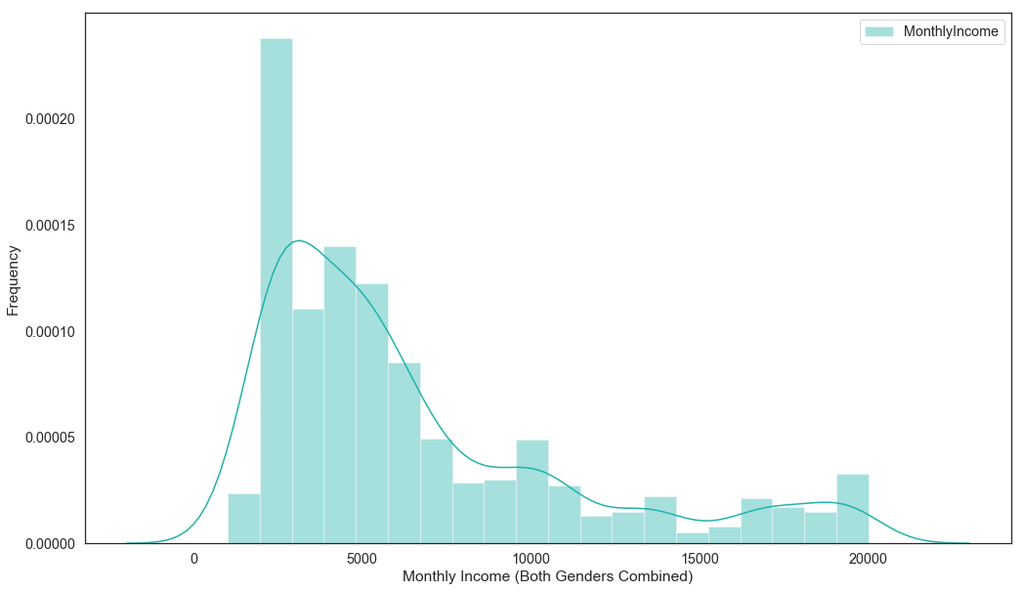

```python
# Plot Female and Male in same plot
fig, axes = plt.subplots(1, 1, figsize=(17, 10))
sns.distplot(attrition_data[['MonthlyIncome']], axlabel=None, label='MonthlyIncome', color='lightseagreen')
plt.legend()
plt.xlabel('Monthly Income (Both Genders Combined)')
plt.ylabel('Frequency')
plt.show()
```

By looking at the above distribution for MonthlyIncome, there is a right-skewness, confirming that the MonthlyIncome means calculated earlier is the result of this skew, as a small portion of the datapoints' monthly income is almost 3-4 times more than the the majority of datapoints.

Next, MonthlyIncome distributions by Gender will be plotted to see if any apparent gender difference exists:

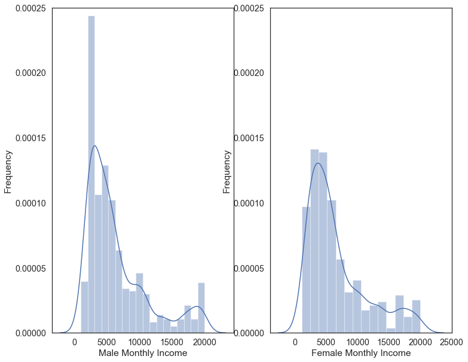

```python
# Plot Female and Male in same plot
fig, axes = plt.subplots(1, 2, figsize=(12, 10))
attrition_data_M = attrition_data.loc[attrition_data['Gender'] == 'Male']
attrition_data_F = attrition_data.loc[attrition_data['Gender'] == 'Female']

sns.distplot(attrition_data_M[['MonthlyIncome']], axlabel=None, label='Male Monthly Income', ax=axes[0])
sns.distplot(attrition_data_F[['MonthlyIncome']], axlabel=None, label='Female Monthly Income', ax=axes[1])
axes[0].set_xlabel("Male Monthly Income")
axes[0].set_ylabel("Frequency")
axes[1].set_xlabel("Female Monthly Income")
axes[1].set_ylabel("Frequency")
ylim = [0, .00025]
axes[0].set_ylim(ylim)
axes[1].set_ylim(ylim)
plt.show()
```

A superimposed version of the above distributions for an easier comparison:

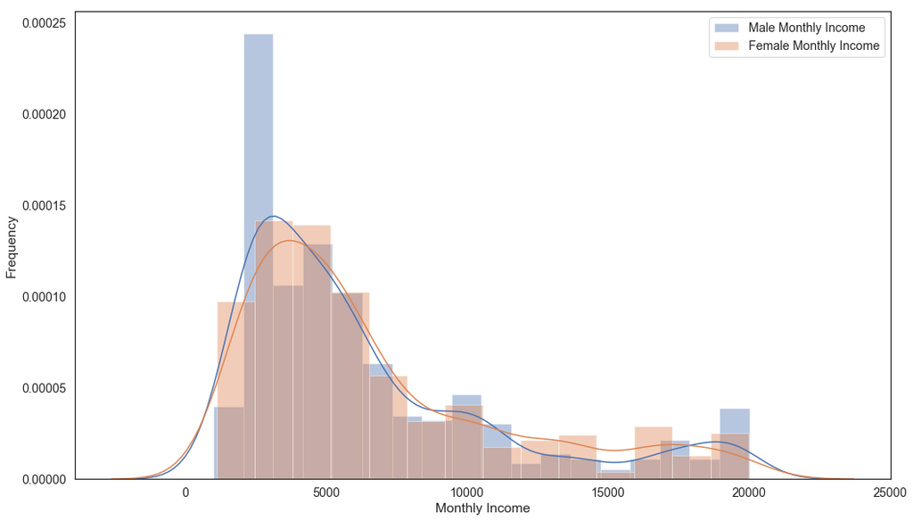

```python
# Plot Female and Male in same plot
fig, axes = plt.subplots(1, 1, figsize=(17, 10))
attrition_data_M = attrition_data.loc[attrition_data['Gender'] == 'Male']
attrition_data_F = attrition_data.loc[attrition_data['Gender'] == 'Female']

sns.distplot(attrition_data_M[['MonthlyIncome']], axlabel=None, label='Male Monthly Income')
sns.distplot(attrition_data_F[['MonthlyIncome']], axlabel=None, label='Female Monthly Income')
plt.legend()
plt.xlabel('Monthly Income')
plt.ylabel('Frequency')
plt.show()
```

In terms of the shapes of the distributions, there is no apparent difference in distributions between the genders.  
Next, all the income related numeric data -MonthlyIncome, DailyRate, HourlyRate, and MonthlyRate are plotted for both gender combined to see their respective distributions:

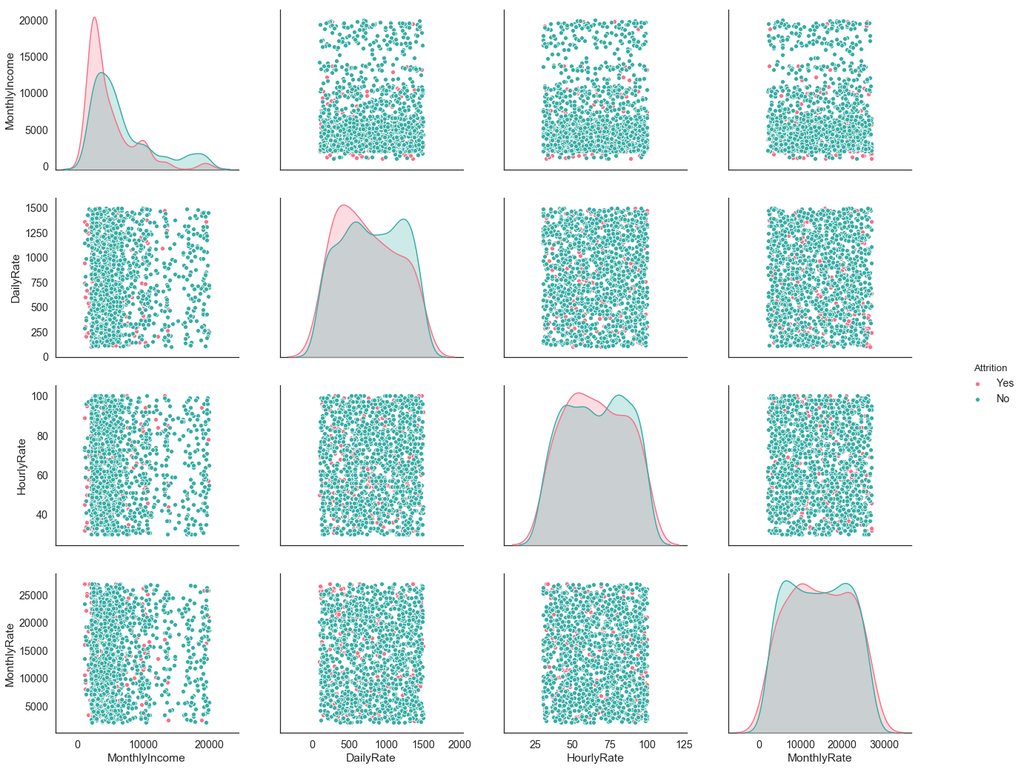

```python
g = sns.pairplot(attrition_data, x_vars=["MonthlyIncome", "DailyRate", "HourlyRate", "MonthlyRate"],
                 y_vars=["MonthlyIncome", "DailyRate", "HourlyRate", "MonthlyRate"], hue='Attrition',
                 palette="husl")
g.fig.set_figheight(15)
g.fig.set_figwidth(20)
```

By default, this function will create a grid of Axes such that each variable in data will by shared in the y-axis across a single row and in the x-axis across a single column. The diagonal Axes are treated differently, drawing a plot to show the univariate distribution of the data for the variable in that column.

To make the visual analysis easier, the MonthlyIncome values are convered into ranges (brackets), in which each MonthlyIncome values are categorized into:

```python
step = 2500
for start in range(0, attrition_data['MonthlyIncome'].max(), step):
  # 0 2500 5000
  rows = (attrition_data['MonthlyIncome'] >= start) & (attrition_data['MonthlyIncome'] <= start + step)
  attrition_data.loc[rows, 'MonthlyIncomeBracket'] = start + step
attrition_data.head()
```

| EmployeeNumber | Age | Attrition | BusinessTravel | DailyRate | Department | DistanceFromHome | Education | EducationField | EmployeeCount | EnvironmentSatisfaction | ... | StandardHours | StockOptionLevel | TotalWorkingYears | TrainingTimesLastYear | WorkLifeBalance | YearsAtCompany | YearsInCurrentRole | YearsSinceLastPromotion | YearsWithCurrManager | MonthlyIncomeBracket |
| --- | --- | --- | --- | --- | --- | --- | --- | --- | --- | --- | --- | --- | --- | --- | --- | --- | --- | --- | --- | --- | --- |
| 1 | 41 | Yes | Travel_Rarely | 1102 | Sales | 1 | 2 | Life Sciences | 1 | 2 | ... | 80 | 0 | 8 | 0 | 1 | 6 | 4 | 0 | 5 | 7500.0 |
| 2 | 49 | No | Travel_Frequently | 279 | Research & Development | 8 | 1 | Life Sciences | 1 | 3 | ... | 80 | 1 | 10 | 3 | 3 | 10 | 7 | 1 | 7 | 7500.0 |
| 4 | 37 | Yes | Travel_Rarely | 1373 | Research & Development | 2 | 2 | Other | 1 | 4 | ... | 80 | 0 | 7 | 3 | 3 | 0 | 0 | 0 | 0 | 2500.0 |
| 5 | 33 | No | Travel_Frequently | 1392 | Research & Development | 3 | 4 | Life Sciences | 1 | 4 | ... | 80 | 0 | 8 | 3 | 3 | 8 | 7 | 3 | 0 | 5000.0 |
| 7 | 27 | No | Travel_Rarely | 591 | Research & Development | 2 | 1 | Medical | 1 | 1 | ... | 80 | 1 | 6 | 3 | 3 | 2 | 2 | 2 | 2 | 5000.0 |

5 rows × 35 columns

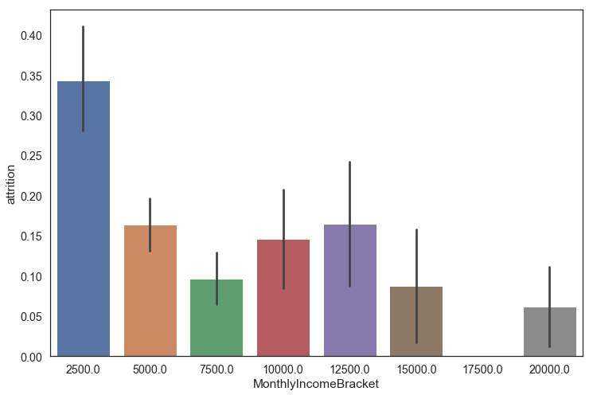

```python
fig, ax = plt.subplots(1, figsize=(12, 8))
attrition_data['attrition'] = attrition_data['Attrition'].replace({'Yes': 1, 'No': 0})
sns.barplot(x='MonthlyIncomeBracket', y='attrition', data=attrition_data)
plt.show()
```

#### (1) Visualizing the relationship between MonthlyIncome and Attrition:

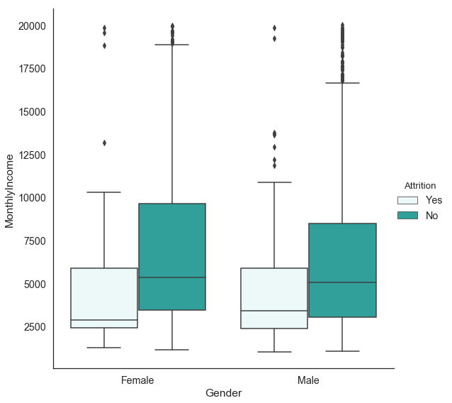

```python
#fig,axes = plt.subplots(1, figsize=(20,8))
g = sns.catplot(x='Gender', y='MonthlyIncome', hue='Attrition', data=attrition_data, kind='box', height=8,
                aspect=1, color="lightseagreen")
plt.show()
```

#### (2) Visualizing the relationship between HourlyRate and Attrition:

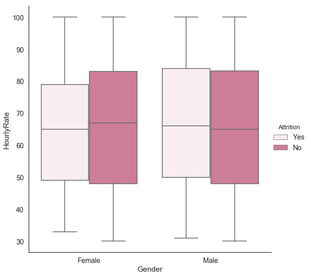

```python
g = sns.catplot(x='Gender', y='HourlyRate', hue='Attrition', data=attrition_data, kind='box', height=8,
                aspect=1, color='palevioletred')
plt.show()
```

#### (3) Visualizing the relationship between DailyRate and Attrition:

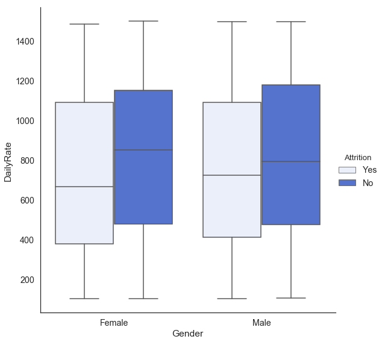

```python
g = sns.catplot(x='Gender', y='DailyRate', hue='Attrition', data=attrition_data, kind='box', height=8,
                aspect=1, color='royalblue')
plt.show()
```

#### (4) Visualizing the relationship between MonthlyRate and Attrition:

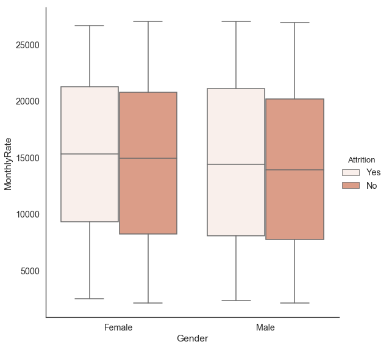

```python
g = sns.catplot(x='Gender', y='MonthlyRate', hue='Attrition', data=attrition_data,
                kind='box', height=8, aspect=1, color='darksalmon')
plt.show()
```

#### Observations from the boxplots (1) to (4):

(2) The distibutions for DailyRate also show that the individuals with Attrition/Yes tends to have the lower incomes in both genders. The means for the HourlyRate discrepancy for the female shows that the incomes for the 50 percentile are approximately 660 dollars for Attrition/Yes group while it is about 830 dollars for Attrition/No group. The same is true for the male counterparts. While the discrepancy is not as wide as the female one, the differences between the means are approximately between 700 dollars to 750 dollars, which can make a significant difference in their paychecks (Note: No outliers exist).

(3) The distributions for HourlyRate indicates that the female Attrition/Yes earn less than the Attrition/No group while the male Attrition/Yes grouyp earning slightly more than its Attrition/No group.

(5) Although not all the distributuions show that the lower rates of income/wages always indicate higher Attrition/Yes, more than half the distributuions above may warrant the following hypothesis:

H0: The lower income/wages have no effect on the job attrition.  
H1: The lower income/wages does have an effect on the job attrition.

(6) To test the hypothesis, t-test is performed as follows:

```python
stats.ttest_ind(attrition_data[attrition_data.Attrition == 'Yes']['MonthlyIncome'],
                attrition_data[attrition_data.Attrition == 'No']['MonthlyIncome'])
```

```
Ttest_indResult(statistic=-6.203935765608938, pvalue=7.14736398535381e-10)
```

Results:

- The result of the t-test performed above, the calculated p-value (pvalue=7.14736398535381e-10) is significantly smaller than 0.05.
- This indicates the strong evidence against the null hypothesis H0=Income makes no difference in attrition.
- Therefore, I can safely rejct the null hypothesis, thus conclude that the alternative hypothesis is true, income does make a difference in attrition.

Before concluding the exploration on the question of income and attrtion, the following tabular information is created:

```python
attrition_pivot = attrition_data.pivot_table(index=['Attrition', 'MonthlyIncomeBracket'], columns=['Gender'],
                           values='Age', aggfunc=lambda x: len(x) if len(x) != np.nan else 0, margins=True)
attrition_pivot
```

| Attrition | Gender MonthlyIncomeBracket | Female | Male | All |
| --- | --- | --- | --- | --- |
| No | 2500.0 | 53 | 94 | 147 |
|  | 5000.0 | 175 | 264 | 439 |
|  | 7500.0 | 117 | 163 | 280 |
|  | 10000.0 | 40 | 71 | 111 |
|  | 12500.0 | 34 | 42 | 76 |
|  | 15000.0 | 30 | 22 | 52 |
|  | 17500.0 | 28 | 24 | 52 |
|  | 20000.0 | 24 | 52 | 76 |
| Yes | 2500.0 | 25 | 52 | 77 |
|  | 5000.0 | 36 | 50 | 86 |
|  | 7500.0 | 10 | 20 | 30 |
|  | 10000.0 | 9 | 10 | 19 |
|  | 12500.0 | 3 | 12 | 15 |
|  | 15000.0 | 1 | 4 | 5 |
|  | 20000.0 | 3 | 2 | 5 |
| All |  | 588 | 882 | 1470 |

To put the above numbers in perspective, the following pivot table is created to see the gender ratios for each monthly income brackets:

```python
attrition_pivot = attrition_pivot.rename(index={'All': 'Total'}, columns={'All': 'Total'})
attrition_pivot.loc[:, 'Male'] = (attrition_pivot.loc[:, 'Male'] / attrition_pivot.loc[:, 'Total']) * 100
attrition_pivot.loc[:, 'Female'] = (attrition_pivot.loc[:, 'Female'] / attrition_pivot.loc[:, 'Total']) * 100
attrition_pivot.loc[:, 'total_prcnt'] = (attrition_pivot.loc[:, 'Total'] / attrition_pivot.loc[:, 'Total']) * 100
attrition_pivot
```

| Attrition | Gender MonthlyIncomeBracket | Female | Male | Total | total_prcnt |
| --- | --- | --- | --- | --- | --- |
| No | 2500.0 | 36.054422 | 63.945578 | 147 | 100.0 |
|  | 5000.0 | 39.863326 | 60.136674 | 439 | 100.0 |
|  | 7500.0 | 41.785714 | 58.214286 | 280 | 100.0 |
|  | 10000.0 | 36.036036 | 63.963964 | 111 | 100.0 |
|  | 12500.0 | 44.736842 | 55.263158 | 76 | 100.0 |
|  | 15000.0 | 57.692308 | 42.307692 | 52 | 100.0 |
|  | 17500.0 | 53.846154 | 46.153846 | 52 | 100.0 |
|  | 20000.0 | 31.578947 | 68.421053 | 76 | 100.0 |
| Yes | 2500.0 | 32.467532 | 67.532468 | 77 | 100.0 |
|  | 5000.0 | 41.860465 | 58.139535 | 86 | 100.0 |
|  | 7500.0 | 33.333333 | 66.666667 | 30 | 100.0 |
|  | 10000.0 | 47.368421 | 52.631579 | 19 | 100.0 |
|  | 12500.0 | 20.000000 | 80.000000 | 15 | 100.0 |
|  | 15000.0 | 20.000000 | 80.000000 | 5 | 100.0 |
|  | 20000.0 | 60.000000 | 40.000000 | 5 | 100.0 |
| Total |  | 40.000000 | 60.000000 | 1470 | 100.0 |

Observations:  
It is interesting to see that some of the income groups has a similar ratio to the overall dataset ratio (female:4, male:6).  
For example, looking at the groups for Attrtion/No, the gender ratio (percentage) for female is anywhere approximately between 36% to 45% for the income groups between 2500 and 12500, staying withing the 10% range of the 40%.  
The 15000 dollar group for female Attrtion/No is almost 58%, the highest percentage, for the female Attrtion/No group. Together with the 17500 dollar group, female in these income category show higher percentage than that of the males though the percentage dramatically decreases for 20000 group.

Next, the topic of the Job Role/Job Level and Attrtion is investigated.

### Exploratory Question: *"Can Job Level and/or Job Role affect Attrition?"*:

Notes on the relevant columns: This topic involves categorical data mainly, JobLevel and JobRole.  
As mentioned earlier, JobLevel consists of 1 to 5 categories while JobRole consists of 9 job titles, (e.g.) Sales Representative, etc. There is no clear group, or demarcations between the JobLevel and JobRoles. For instance, JobLevel 1 includes the JobRoles such as Sales Representative, Laboratory Technicians, Research Scientist, etc, while JobLevel 2 can include all the said JobRoles. For example, JobRole, "Manager" appears in JobLevel 3, 4, and 5. That said, it is important to note that the lower number the JobLevel is, the income is lower as shown in the below plot:

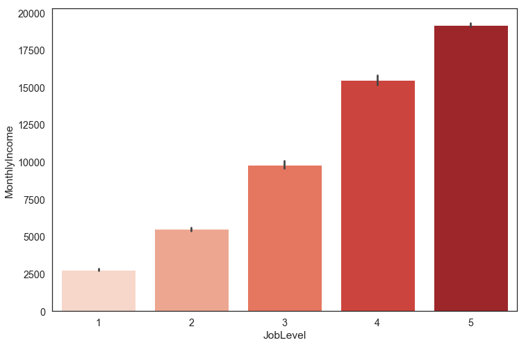

```python
fig, ax = plt.subplots(1, figsize=(12, 8))
sns.barplot(x='JobLevel', y='MonthlyIncome', data=attrition_data, palette='Reds')
plt.show()
```

First, a simple bar plot is created against Attrtion to see if a general trend exists.

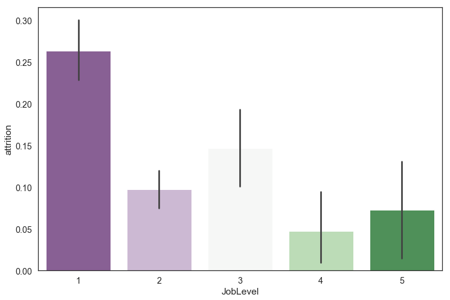

```python
fig, ax = plt.subplots(1, figsize=(12, 8))
sns.barplot(x='JobLevel', y='attrition', data=attrition_data, palette='PRGn')
plt.show()
```

Although there is no clean and clear trend is seen, the JobLevel 1 clearly indicates the group's vulnerability to job attrtion. The figure for this group, 0.26-0.27 is much higher than the ones for JobLevel 4 and 5 ranging from approximately 0.04 to 0.075. This observation is further confirmed by creating the following crosstab shwoing the percentages for each group.

```python
joblevel = pd.crosstab(attrition_data['Attrition'], attrition_data['JobLevel'], margins=True, normalize=True)
joblevel * 100
```

| JobLevel Attrition | 1 | 2 | 3 | 4 | 5 | All |
| --- | --- | --- | --- | --- | --- | --- |
| No | 27.210884 | 32.789116 | 12.653061 | 6.870748 | 4.353741 | 83.877551 |
| Yes | 9.727891 | 3.537415 | 2.176871 | 0.340136 | 0.340136 | 16.122449 |
| All | 36.938776 | 36.326531 | 14.829932 | 7.210884 | 4.693878 | 100.000000 |

H0: The JobLevel has no effect on Attrition. H1: The JobLevel does have an effect on Attrition (H0 is not True).

One-Way ANOVA will be performed to test this hypothesis. To do so, a list needs to be created first so that the list variable can be passed onto the inside .f_oneway().

```python
joblevels = []
for i in range(1, 6):
  jl = attrition_data.loc[attrition_data['JobLevel'] == i, 'attrition']
  joblevels.append(jl)
stats.f_oneway(*joblevels)
```

```
F_onewayResult(statistic=19.0084454700361, pvalue=2.975150100310332e-15)
```

The calculated pvalue=2.975150100310332e-15, significantly smaller than 0.05. Therefore, I can safely reject the null hypothesis (H0: The JobLevel has no effect in Attrition).

To investigate further, another relevant column, JobRole will be analyzed in a similar fashion.

First, a simple barplot is created for JobRoles agaisnt Attrition as follows:

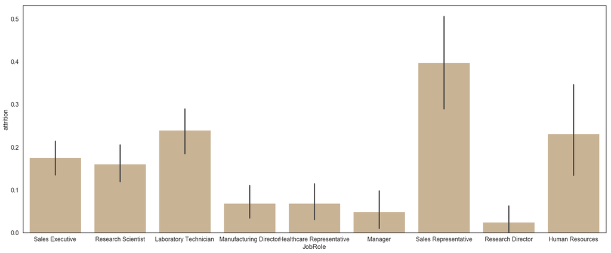

```python
fig, ax = plt.subplots(1, figsize=(25, 10))
sns.barplot(x='JobRole', y='attrition', data=attrition_data, color='tan')
plt.show()
```

The bargraph above indicates that the Sales Representative, Laboratory Technician, and Human Resources professionals seem more vulnerable to job attrition compared to their counterparts.

The following pivot table and crosstab are created to see the relationship between JobLevel and JobRole.

```python
levelandrole_pivot = attrition_data.pivot_table(index=['JobRole'], columns=['JobLevel'],
                           values='Attrition', aggfunc=lambda x: len(x) if len(x) != np.nan else 0, margins=True)
levelandrole_pivot
```

| JobLevel JobRole | 1 | 2 | 3 | 4 | 5 | All |
| --- | --- | --- | --- | --- | --- | --- |
| Healthcare Representative | NaN | 78.0 | 44.0 | 9.0 | NaN | 131 |
| Human Resources | 33.0 | 13.0 | 6.0 | NaN | NaN | 52 |
| Laboratory Technician | 200.0 | 56.0 | 3.0 | NaN | NaN | 259 |
| Manager | NaN | NaN | 12.0 | 47.0 | 43.0 | 102 |
| Manufacturing Director | NaN | 90.0 | 45.0 | 10.0 | NaN | 145 |
| Research Director | NaN | NaN | 28.0 | 26.0 | 26.0 | 80 |
| Research Scientist | 234.0 | 57.0 | 1.0 | NaN | NaN | 292 |
| Sales Executive | NaN | 233.0 | 79.0 | 14.0 | NaN | 326 |
| Sales Representative | 76.0 | 7.0 | NaN | NaN | NaN | 83 |
| All | 543.0 | 534.0 | 218.0 | 106.0 | 69.0 | 1470 |

```python
jobrole = pd.crosstab(attrition_data['Attrition'], attrition_data['JobRole'], margins=True,
                      normalize=True)
jobrole * 100
```

| JobRole Attrition | Healthcare Representative | Human Resources | Laboratory Technician | Manager | Manufacturing Director | Research Director | Research Scientist | Sales Executive | Sales Representative | All |
| --- | --- | --- | --- | --- | --- | --- | --- | --- | --- | --- |
| No | 8.299320 | 2.721088 | 13.401361 | 6.598639 | 9.183673 | 5.306122 | 16.666667 | 18.299320 | 3.401361 | 83.877551 |
| Yes | 0.612245 | 0.816327 | 4.217687 | 0.340136 | 0.680272 | 0.136054 | 3.197279 | 3.877551 | 2.244898 | 16.122449 |
| All | 8.911565 | 3.537415 | 17.619048 | 6.938776 | 9.863946 | 5.442177 | 19.863946 | 22.176871 | 5.646259 | 100.000000 |

As the table above indicates, the JobRoles such as Sales Representative, Laboratory Technician,  
and Human Resources professionals occupy the lower JobLevel, mostly in 1, followed by 2, and very few in 3. As seen earlier, the JobLevel 1 is the group that is particularly high in job attrtion.

The following hypothesis is formed as the result of this observations: H0: JobRole has no effect on Attrtion H1: JobRole does have an effect on Attrtion (H0 is not True).

```python
jobroles = []
for j in attrition_data['JobRole'].unique():
  jr = attrition_data.loc[attrition_data['JobRole'] == j, 'attrition']
  jobroles.append(jr)
  # anova needs a list to be paassed onto
print(len(jobroles))
stats.f_oneway(*jobroles)
```

```
9
```

```
F_onewayResult(statistic=11.374753732967797, pvalue=9.562555450860023e-16)
```

The calculated pvalue=9.562555450860023e-16, is significantly smaller than 0.05. Therefore, I can safely reject the null hypothesis (H0: The JobRole has no effect in Attrition).

For the analyses and results of JobLevel and JobRole taken taken togher, I conclude that JobLevel and JobRole may lead to job attrition.

### 3. Hours of Commitment:

To see if the job attrition can be affected by the total time the individuals may have to spend for in and outside the office associated with work, the following columns are analyzed:  
(1) 'DistanceFromHome'  
(2) 'MaritalStatus',  
(3) 'OverTime',  
(4) 'BusinessTravel'

Note: MaritalStatus is included in this analysis based on the possibility that whether individual is single, married, or divorced, may play a role in the job attrtion especially if one must not only travel but also have to have over time, and/or commuting distance is long. Or, it could be the case that the single ones are more likely to have job attrtitions based on the assumption that they do not have financial obligations to thier families and children, allowing them to feel more at ease about resining. Either way, this column seems to be an interesting one to analyzed together.

The following code is to categorize commuting distances ranging from 1 to 29 to make analysis and subsequent visualization easier:

```python
step = 5
for start in range(0, attrition_data['DistanceFromHome'].max(), step):
  # 0 2500 5000
  rows = (attrition_data['DistanceFromHome'] >= start) & (attrition_data['DistanceFromHome'] <= start + step)
  if start + step > 24:
    attrition_data.loc[rows, 'DistanceRange'] = 25
  else:
    attrition_data.loc[rows, 'DistanceRange'] = start + step
attrition_data.head()
```

| EmployeeNumber | Age | Attrition | BusinessTravel | DailyRate | Department | DistanceFromHome | Education | EducationField | EmployeeCount | EnvironmentSatisfaction | ... | TotalWorkingYears | TrainingTimesLastYear | WorkLifeBalance | YearsAtCompany | YearsInCurrentRole | YearsSinceLastPromotion | YearsWithCurrManager | MonthlyIncomeBracket | attrition | DistanceRange |
| --- | --- | --- | --- | --- | --- | --- | --- | --- | --- | --- | --- | --- | --- | --- | --- | --- | --- | --- | --- | --- | --- |
| 1 | 41 | Yes | Travel_Rarely | 1102 | Sales | 1 | 2 | Life Sciences | 1 | 2 | ... | 8 | 0 | 1 | 6 | 4 | 0 | 5 | 7500.0 | 1 | 5.0 |
| 2 | 49 | No | Travel_Frequently | 279 | Research & Development | 8 | 1 | Life Sciences | 1 | 3 | ... | 10 | 3 | 3 | 10 | 7 | 1 | 7 | 7500.0 | 0 | 10.0 |
| 4 | 37 | Yes | Travel_Rarely | 1373 | Research & Development | 2 | 2 | Other | 1 | 4 | ... | 7 | 3 | 3 | 0 | 0 | 0 | 0 | 2500.0 | 1 | 5.0 |
| 5 | 33 | No | Travel_Frequently | 1392 | Research & Development | 3 | 4 | Life Sciences | 1 | 4 | ... | 8 | 3 | 3 | 8 | 7 | 3 | 0 | 5000.0 | 0 | 5.0 |
| 7 | 27 | No | Travel_Rarely | 591 | Research & Development | 2 | 1 | Medical | 1 | 1 | ... | 6 | 3 | 3 | 2 | 2 | 2 | 2 | 5000.0 | 0 | 5.0 |

5 rows × 37 columns

The following is the summary of the selected columns, in which 'DistanceRange' is a new column as the result of the above code to categorize 'DistanceFromHome'.

```python
# Hours of Commitment's relevant colums in a pivot table:
attrition_pivot = attrition_data.pivot_table(index=['OverTime', 'BusinessTravel', 'DistanceRange', 'MaritalStatus'],
                                             columns=['Gender','Attrition'], values='Age',
                                             aggfunc=lambda x: len(x) if len(x) != np.nan else 0, margins=True)
attrition_pivot
```

| OverTime | BusinessTravel | DistanceRange | Gender Attrition MaritalStatus | Female No | Female Yes | Male No | Male Yes | All |
| --- | --- | --- | --- | --- | --- | --- | --- | --- |
| No | Non-Travel | 5.0 | Divorced | 2.0 | NaN | 10.0 | NaN | 12 |
|  |  |  | Married | 8.0 | NaN | 17.0 | NaN | 25 |
|  |  |  | Single | 4.0 | NaN | 3.0 | NaN | 7 |
|  |  | 10.0 | Divorced | 1.0 | NaN | 10.0 | 1.0 | 12 |
|  |  |  | Married | 4.0 | NaN | 3.0 | NaN | 7 |
|  |  |  | Single | 2.0 | NaN | 11.0 | 1.0 | 14 |
|  |  | 15.0 | Divorced | 1.0 | NaN | NaN | NaN | 1 |
|  |  |  | Married | 2.0 | NaN | 2.0 | 1.0 | 5 |
|  |  |  | Single | 1.0 | NaN | 3.0 | NaN | 4 |
|  |  | 20.0 | Divorced | 1.0 | NaN | 2.0 | NaN | 3 |
|  |  |  | Married | NaN | NaN | 1.0 | NaN | 1 |
|  |  |  | Single | NaN | NaN | 4.0 | NaN | 4 |
|  |  | 25.0 | Divorced | 2.0 | NaN | 2.0 | NaN | 4 |
|  |  |  | Married | 4.0 | NaN | 5.0 | NaN | 9 |
|  |  |  | Single | 1.0 | NaN | 4.0 | 2.0 | 7 |
|  | Travel_Frequently | 5.0 | Divorced | 7.0 | NaN | 7.0 | 3.0 | 17 |
|  |  |  | Married | 11.0 | NaN | 18.0 | 1.0 | 30 |
|  |  |  | Single | 9.0 | 5.0 | 13.0 | 4.0 | 31 |
|  |  | 10.0 | Divorced | 1.0 | 2.0 | 8.0 | NaN | 11 |
|  |  |  | Married | 8.0 | NaN | 11.0 | 3.0 | 22 |
|  |  |  | Single | 4.0 | 1.0 | 2.0 | 1.0 | 8 |
|  |  | 15.0 | Divorced | 3.0 | NaN | 5.0 | 1.0 | 9 |
|  |  |  | Married | 3.0 | NaN | 6.0 | 1.0 | 10 |
|  |  |  | Single | 2.0 | 2.0 | 3.0 | NaN | 7 |
|  |  | 20.0 | Divorced | 1.0 | NaN | 1.0 | NaN | 2 |
|  |  |  | Married | 2.0 | NaN | 3.0 | 1.0 | 6 |
|  |  |  | Single | 2.0 | NaN | 2.0 | NaN | 4 |
|  |  | 25.0 | Divorced | 3.0 | NaN | 2.0 | NaN | 5 |
|  |  |  | Married | 8.0 | 2.0 | 6.0 | 1.0 | 17 |
|  |  |  | Single | 6.0 | 2.0 | 1.0 | 3.0 | 12 |
| ... | ... | ... | ... | ... | ... | ... | ... | ... |
| Yes | Travel_Frequently | 5.0 | Married | 3.0 | NaN | 7.0 | 3.0 | 13 |
|  |  |  | Single | 4.0 | 3.0 | 6.0 | 3.0 | 16 |
|  |  | 10.0 | Divorced | 1.0 | NaN | 4.0 | NaN | 5 |
|  |  |  | Married | NaN | 3.0 | 3.0 | 1.0 | 7 |
|  |  |  | Single | 1.0 | 3.0 | 1.0 | 3.0 | 8 |
|  |  | 15.0 | Divorced | NaN | NaN | 2.0 | NaN | 2 |
|  |  |  | Married | NaN | NaN | 1.0 | NaN | 1 |
|  |  |  | Single | 1.0 | 1.0 | NaN | 2.0 | 4 |
|  |  | 20.0 | Divorced | NaN | 1.0 | 1.0 | 1.0 | 3 |
|  |  |  | Married | NaN | 1.0 | 3.0 | 1.0 | 5 |
|  |  |  | Single | NaN | 1.0 | NaN | NaN | 1 |
|  |  | 25.0 | Divorced | 1.0 | 2.0 | NaN | 1.0 | 4 |
|  |  |  | Married | 3.0 | NaN | 3.0 | 1.0 | 7 |
|  |  |  | Single | 1.0 | 1.0 | 1.0 | 2.0 | 5 |
|  | Travel_Rarely | 5.0 | Divorced | 9.0 | 3.0 | 6.0 | NaN | 18 |
|  |  |  | Married | 15.0 | 3.0 | 22.0 | 8.0 | 48 |
|  |  |  | Single | 14.0 | 5.0 | 10.0 | 8.0 | 37 |
|  |  | 10.0 | Divorced | 9.0 | 1.0 | 14.0 | 2.0 | 26 |
|  |  |  | Married | 13.0 | 2.0 | 12.0 | 5.0 | 32 |
|  |  |  | Single | 5.0 | 2.0 | 6.0 | 6.0 | 19 |
|  |  | 15.0 | Divorced | 7.0 | NaN | 3.0 | 3.0 | 13 |
|  |  |  | Married | 10.0 | 2.0 | 10.0 | 1.0 | 23 |
|  |  |  | Single | 2.0 | 3.0 | 1.0 | 3.0 | 9 |
|  |  | 20.0 | Divorced | 2.0 | NaN | 3.0 | 2.0 | 7 |
|  |  |  | Married | 5.0 | NaN | 5.0 | 2.0 | 12 |
|  |  |  | Single | 3.0 | 2.0 | NaN | 1.0 | 6 |
|  |  | 25.0 | Divorced | 1.0 | NaN | 2.0 | 1.0 | 4 |
|  |  |  | Married | 6.0 | 3.0 | 12.0 | 5.0 | 26 |
|  |  |  | Single | 2.0 | 2.0 | 2.0 | 9.0 | 15 |
| All |  |  |  | 501.0 | 87.0 | 732.0 | 150.0 | 1470 |

90 rows × 5 columns

#### (1) Visualizing the relatipnship between "DistanceFromHome" and "Attrition":

First, plotting DistanceRange and Attrtion in a simple bar graph.

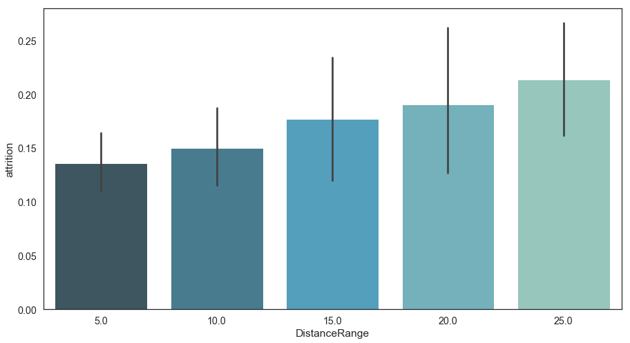

```python
fig, ax = plt.subplots(1, figsize=(15, 8))
sns.barplot(x='DistanceRange', y='attrition', data=attrition_data, palette="GnBu_d")
plt.show()
```

Nextly, similarly for the MaritalStatus and Attrition, a bargraph is plotted.

#### (2) Visualizing the relatipnship between "MaritalStatus" and "Attrition":

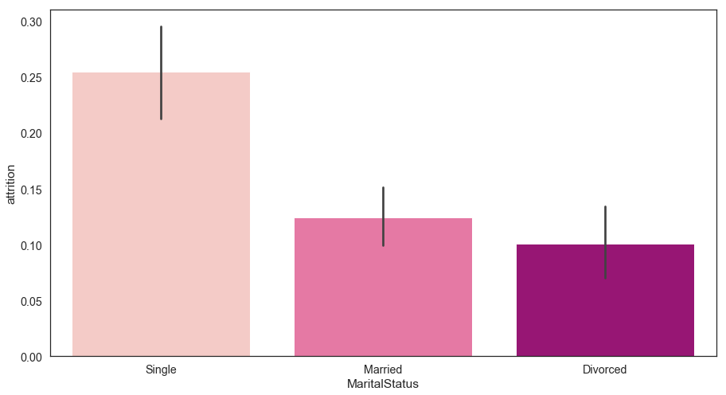

```python
fig, ax = plt.subplots(1, figsize=(15, 8))
sns.barplot(x='MaritalStatus', y='attrition', data=attrition_data, palette="RdPu")
plt.show()
```

The bargraph above shows that the Single group is more likely to lead to job attrition with much higher number, little over 0.25, than the ones for Married, and Divorced groups. This may be because of the fact that, as brieflymentioned earlier, the singles are likely to have less obligations to family and children.  
Comparing the Single and the Divorced, one may think that why they are strikingly so different although divorced means they are single in a general categorical sense. However, the difference between the Single and the Divorced may be large because of the potential financial burdens that the Divorced group may have to their former spourses, and especially to their children. Compared to the Married group, the Divorced group cannot enjoy the tax benefits of filing tax jointly, which is often done by married couples. The Divorced group is also more vulnerable to less healthcare benefits compared to its married counterparts. With the aforesaid potential financial burdens, the tax, the healthcare, and possibly more, it is after costly to live the life alone while being fiancially responsible for others. Whatever the true cauases may be, this is an interesting graph to see.

#### (3) Visualizing the relatipnship between "OverTime" and "Attrition":

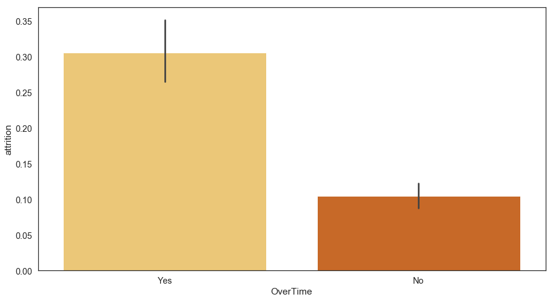

```python
fig, ax = plt.subplots(1, figsize=(15, 8))
sns.barplot(x='OverTime', y='attrition', data=attrition_data, palette="YlOrBr")
plt.show()
```

#### (4) Visualizing the relatipnship between "BusinessTravel" and "Attrition":

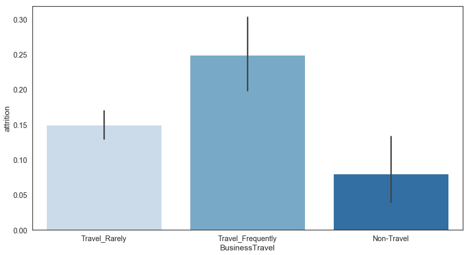

```python
fig, ax = plt.subplots(1, figsize=(15, 8))
sns.barplot(x='BusinessTravel', y='attrition', data=attrition_data, palette="Blues")
plt.show()
```

The bar graph above also shows a trend that the more one travels, the more the individual is likely to have Attrtion/Yes.

Finally, One-Way ANOVA will be performd to test the following hypotheses for each column analyzed above:

(1) The DistanceFromHome:  
H0: The commuting distance has no effect in job attrition.  
H1: The commuting distance does affect job attrition (H0 is not True).

(2) MaritalStatus:  
H0: The marital status has no effect in job attrition.  
H1: The marital status distance does affect job attrition (H0 is not True).

(3) OverTime:  
H0: The over time has no effect in job attrition.  
H1: The over time does affect job attrition (H0 is not True).

(4) BusinessTravel:  
H0: The business travel frequency has no effect in job attrition.  
H1: The business travel frequency does affect job attrition (H0 is not True).

First, testing for (1) The DistanceFromHome:  
H0: The commuting distance has no effect in job attrition.  
H1: The commuting distance does affect job attrition (H0 is not True).

```python
distance = pd.crosstab(attrition_data['Attrition'], attrition_data['DistanceRange'],
                       margins=True, normalize=True)
distance * 100
```

| DistanceRange Attrition | 5.0 | 10.0 | 15.0 | 20.0 | 25.0 | All |
| --- | --- | --- | --- | --- | --- | --- |
| No | 33.333333 | 21.564626 | 9.795918 | 6.938776 | 12.244898 | 83.877551 |
| Yes | 5.238095 | 3.809524 | 2.108844 | 1.632653 | 3.333333 | 16.122449 |
| All | 38.571429 | 25.374150 | 11.904762 | 8.571429 | 15.578231 | 100.000000 |

```python
distances = []
mind = int(attrition_data['DistanceRange'].min())
maxd = int(attrition_data['DistanceRange'].max())
for d in range(mind, maxd + 1, 5):
  dist = attrition_data.loc[attrition_data['DistanceRange'] == d, 'attrition']
  distances.append(dist)
  # anova needs a list to be paassed onto
print(len(distances))
stats.f_oneway(*distances)
```

```
5
```

```
F_onewayResult(statistic=2.227412086976853, pvalue=0.0639418609871053)
```

The p-value=0.063, meaning that I cannot reject the null hypothesis.

This was an unintuitive result for me as I would have guessed that the longer the travel, the more attrtion is likely. That said, a potential explation to this is that even the longest 29 in the dataset the one must ravel (assuming it is in miles) may not be considered too much of a commute after all. This is because for the country such as the United States, 29miles are not a long distance if there is a highway access. This also is relevant whether the company is located in a city, where there is a constant heavy traffic, or located in a rural area with no traffic at all.  
Either way, it is an interesting result.

Next, testing for (2) MaritalStatus:  
H0: The marital status has no effect in job attrition.  
H1: The marital status distance does affect job attrition (H0 is not True).

```python
mss = []
for val in attrition_data['MaritalStatus'].unique():
  ms = attrition_data.loc[attrition_data['MaritalStatus'] == val, 'attrition']
  mss.append(ms)

print(len(mss))
stats.f_oneway(*mss)
```

```
3
```

```
F_onewayResult(statistic=23.78156546845813, pvalue=6.850067559825624e-11)
```

Based on the p-value=6.85e-11, and I can safely reject the null hypothesis, meaning that H1 is true: The marital status distance does affect job attrition. For the potential reasons discussed earlier, they may be a variety of causes to why MaritalStatus does affect job attrition. As the Single group is the most likely to have job attrition, this may be related to Age rather than the MaritalStatus in itself.

The next, testing for (3) OverTime:  
H0: The over time has no effect in job attrition.  
H1: The over time does affect job attrition (H0 is not True).

```python
ots = []
for val in attrition_data['OverTime'].unique():
  ot = attrition_data.loc[attrition_data['OverTime'] == val, 'attrition']
  ots.append(ot)
  # anova needs a list to be paassed onto
print(len(ots))
stats.f_oneway(*ots)
```

```
2
```

```
F_onewayResult(statistic=94.65645707175152, pvalue=1.0092540336562444e-21)
```

Based on the very low pvalue=1.0092540336562444e-21, I can safely reject the null hypothesis (H0: The over time has no effect in job attrition. ), meaning that the over time does affect job attrition. This is an intuitive result, as I know based on my own experience that too long of working hours can lead to 'burn out', leading to the workers to resign.

Finally, testing for (4) BusinessTravel:  
H0: The business travel frequency has no effect in job attrition.  
H1: The business travel frequency does affect job attrition (H0 is not True).

```python
bts = []
for val in attrition_data['BusinessTravel'].unique():
  bt = attrition_data.loc[attrition_data['BusinessTravel'] == val, 'attrition']
  bts.append(bt)

print(len(bts))
stats.f_oneway(*bts)
```

```
3
```

```
F_onewayResult(statistic=12.26835294184309, pvalue=5.1998333569549645e-06)
```

Based on the pvalue=5.1998333569549645e-06, I can safely reject the null hypothesis (the business travel frequency has no effect in job attrition.), meaning that the business travel frequency does affect job attrition. This is also an intuitive result, again based my own experiences.  
Traveling often can only enjoyable if they are for leisure. Being stuck at a meeting room outside one's own country, is the same as being stuck in the office at home.

### 4. Gender and Age Differences in Attrition:

#### (1) Gender and Attrition:

```python
attrition_by_gender = attrition_data.pivot_table(index='Gender', columns='Attrition', values='Age',
                                                 aggfunc='count', margins=True)
attrition_by_gender
# Add precentage so that it is easier to see the ratios --> Do later.
```

| Attrition Gender | No | Yes | All |
| --- | --- | --- | --- |
| Female | 501 | 87 | 588 |
| Male | 732 | 150 | 882 |
| All | 1233 | 237 | 1470 |

```python
gender = pd.crosstab(attrition_data['Gender'], attrition_data['Attrition'], margins=True, normalize=True)
gender * 100
```

| Attrition Gender | No | Yes | All |
| --- | --- | --- | --- |
| Female | 34.081633 | 5.918367 | 40.0 |
| Male | 49.795918 | 10.204082 | 60.0 |
| All | 83.877551 | 16.122449 | 100.0 |

To visualize Gender and Attrition, the sns.countplot was used. This is because both the columns are for categorical values: Attrtion: Yes/No, and Gender: Female/Male.

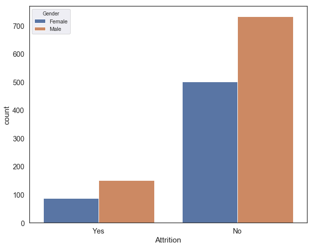

```python
f, ax = plt.subplots(figsize=(10, 8))
sns.set(style="darkgrid")
sns.countplot(x='Attrition', hue="Gender", data=attrition_data)
```

First, as mentioned earlier, the ration in Attrtion (both genders combined) is Attrition/Yes with 16%, and Attrtion/No with 84%.

Taking the results form the crosstab above, in which Looking at the output above, the ratios for the Attrition/Yes and Attrition/No in respective gender are approximately 40% for female and 60% for male.  
H0: The two categorical data (Gender and Attrition) 5.9% of Attrition/Yes is female whle 10.2 of Attrtion/Yes is male. This means that the out of 16%, the total Attrtion/Yes, about 37% are female while the rest, 63% are male, similar to the proportion of female:male, 4:6, included in the dataset.  
This suggests the following hypothesis:

H0: The two categories (Attrtion and Gender) are indepdent of each other. H1: The two categories (Attrtion and Gender) are not indepdent of each other (H0 is not True).

To test these categorical values, the following Chi-Square test is performed:

```python
# Insert your code here
from scipy.stats import chi2_contingency
chi2, p, dof, ex = chi2_contingency(attrition_by_gender)
print("chi2 = ", chi2)
print("p-val = ", p)
print("degree of freedom = ",dof)
print("Expected:")
pd.DataFrame(ex)

### The code needs to be convered from numbers to string values.
```

```
chi2 =  1.2752163602205182
p-val =  0.8655661914618858
degree of freedom =  4
Expected:
```

|  | 0 | 1 | 2 |
| --- | --- | --- | --- |
| 0 | 493.2 | 94.8 | 588.0 |
| 1 | 739.8 | 142.2 | 882.0 |
| 2 | 1233.0 | 237.0 | 1470.0 |

Looking at the p-val = 0.8655661914618858, there is a strong evidence for the null hypothesis (H0: the two categorical data (Gender and Attrition) are independent of each other. In other words, I cannot reject the null hypothesis.

This test result indicates that the potential gender difference I thought we may see is a chance, not due to a dependencies that exists between the two.

My prior was that there is a gender difference in job attrtion as I assumed that female working population is more vulnerable to it due to various social challgenges in and outside work women face. However, after the analysis and the test result, I can deduce that there is no apparent gender difference in attrition because of a self-selecting nature of career options women may be making. For instance, if a woman knows the most of the family obligations fall onto her shoulder (if she has a familly with children), she may not choose the type of work that is likely to make her more hectic to the level that she would end up leaving her workplace.  
This means that she may not be choosing a type of work that is known to have a log of over time, business travels, etc.  
Perhaps, this result is also an indication that this dataset is rick in nature, as many of the factors are hard to separate, interdependent on each other.

#### (2) Age and Attrition:

Finally, Age and Attrition will be analyzed. But first, a new colum, AgeRange will be created to categorize the age data in 'Age' column, which ranges between 18 and 60. The ragnes are divided by 5-year interval, except the first age range (18-25).

```python
step = 5
for start in range(25, attrition_data['Age'].max(), step):
  age_rows = (attrition_data['Age'] >= start) & (attrition_data['Age'] <= start + step)
  if start + step > 59:
    attrition_data.loc[age_rows, 'Age'] = 60
  else:
    attrition_data.loc[age_rows, 'AgeRange'] = start + step
attrition_data.loc[attrition_data['Age'] <= 25, 'AgeRange'] = 25

attrition_data.head()
```

| EmployeeNumber | Age | Attrition | BusinessTravel | DailyRate | Department | DistanceFromHome | Education | EducationField | EmployeeCount | EnvironmentSatisfaction | ... | TrainingTimesLastYear | WorkLifeBalance | YearsAtCompany | YearsInCurrentRole | YearsSinceLastPromotion | YearsWithCurrManager | MonthlyIncomeBracket | attrition | DistanceRange | AgeRange |
| --- | --- | --- | --- | --- | --- | --- | --- | --- | --- | --- | --- | --- | --- | --- | --- | --- | --- | --- | --- | --- | --- |
| 1 | 41 | Yes | Travel_Rarely | 1102 | Sales | 1 | 2 | Life Sciences | 1 | 2 | ... | 0 | 1 | 6 | 4 | 0 | 5 | 7500.0 | 1 | 5.0 | 45.0 |
| 2 | 49 | No | Travel_Frequently | 279 | Research & Development | 8 | 1 | Life Sciences | 1 | 3 | ... | 3 | 3 | 10 | 7 | 1 | 7 | 7500.0 | 0 | 10.0 | 50.0 |
| 4 | 37 | Yes | Travel_Rarely | 1373 | Research & Development | 2 | 2 | Other | 1 | 4 | ... | 3 | 3 | 0 | 0 | 0 | 0 | 2500.0 | 1 | 5.0 | 40.0 |
| 5 | 33 | No | Travel_Frequently | 1392 | Research & Development | 3 | 4 | Life Sciences | 1 | 4 | ... | 3 | 3 | 8 | 7 | 3 | 0 | 5000.0 | 0 | 5.0 | 35.0 |
| 7 | 27 | No | Travel_Rarely | 591 | Research & Development | 2 | 1 | Medical | 1 | 1 | ... | 3 | 3 | 2 | 2 | 2 | 2 | 5000.0 | 0 | 5.0 | 30.0 |

5 rows × 38 columns

Using the newly created column, 'AgeRange', the following pivot table with percentages is created as an overview.

```python
attrition_by_age = attrition_data.pivot_table(index='AgeRange', columns='Attrition', values='Gender',
                                                 aggfunc='count', margins=True)
```

```python
attrition_by_age = attrition_by_age.rename(index={'All': 'Total'}, columns={'All': 'Total'})
attrition_by_age.loc[:, 'no_prcnt'] = (attrition_by_age.loc[:, 'No'] / attrition_by_age.loc[:, 'Total']) * 100
attrition_by_age.loc[:, 'yes_prcnt'] = (attrition_by_age.loc[:, 'Yes'] / attrition_by_age.loc[:, 'Total']) * 100
attrition_by_age.loc[:, 'total_prcnt'] = (attrition_by_age.loc[:, 'Total'] / attrition_by_age.loc[:, 'Total']) * 100
attrition_by_age
```

| Attrition AgeRange | No | Yes | Total | no_prcnt | yes_prcnt | total_prcnt |
| --- | --- | --- | --- | --- | --- | --- |
| 25.0 | 79 | 44 | 123 | 64.227642 | 35.772358 | 100.0 |
| 30.0 | 156 | 47 | 203 | 76.847291 | 23.152709 | 100.0 |
| 35.0 | 266 | 59 | 325 | 81.846154 | 18.153846 | 100.0 |
| 40.0 | 267 | 30 | 297 | 89.898990 | 10.101010 | 100.0 |
| 45.0 | 187 | 21 | 208 | 89.903846 | 10.096154 | 100.0 |
| 50.0 | 128 | 13 | 141 | 90.780142 | 9.219858 | 100.0 |
| 55.0 | 111 | 15 | 126 | 88.095238 | 11.904762 | 100.0 |
| Total | 1194 | 229 | 1423 | 83.907238 | 16.092762 | 100.0 |

First, a histogram with KDE for age distribution is plotted.

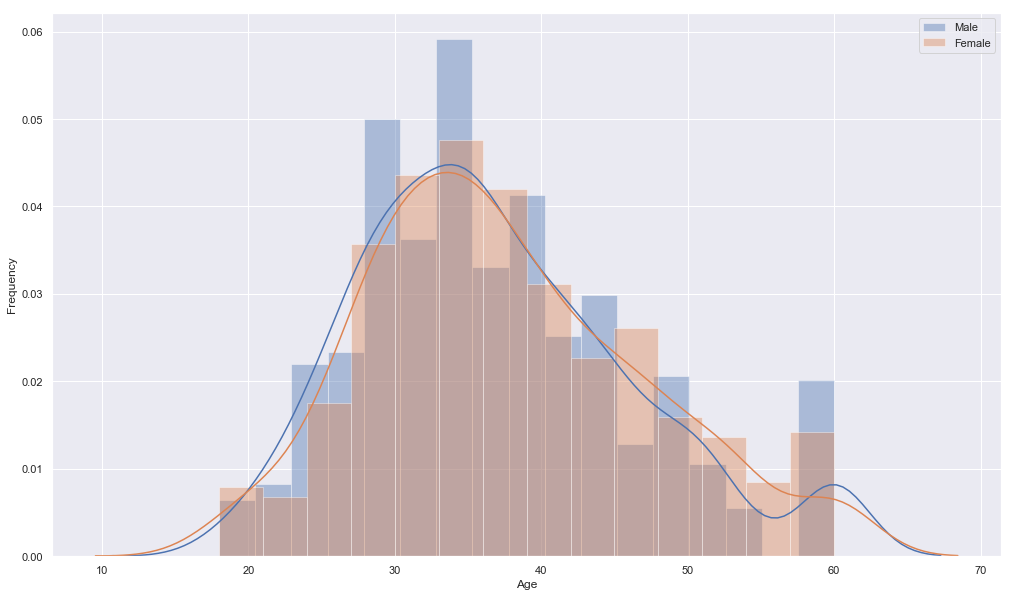

```python
# Plot Female and Male in same plot
fig, axes = plt.subplots(1, 1, figsize=(17, 10))
attrition_data_M = attrition_data.loc[attrition_data['Gender'] == 'Male']
attrition_data_F = attrition_data.loc[attrition_data['Gender'] == 'Female']

sns.distplot(attrition_data_M[['Age']], axlabel=None, label='Male')
sns.distplot(attrition_data_F[['Age']], axlabel=None, label='Female')
plt.legend()
plt.xlabel('Age')
plt.ylabel('Frequency')
plt.show()
```

The following countplot is plotted for AgeRage and Attrition.

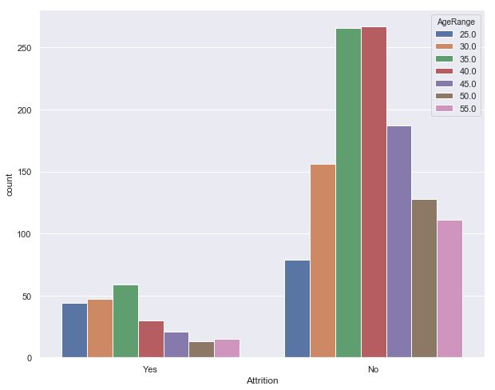

```python
f, ax = plt.subplots(figsize=(10, 8))
sns.set(style="darkgrid")
sns.countplot(x="Attrition", hue="AgeRange", data=attrition_data)
```

Though the y-axis is the total count for the each AgeRange, the graph for Attrition/No appears similar to the KDE normal curve for AgeRange plotted earlier. However, for the Attrition/Yes, the yonger age groups, the 20s and the 30s have higher counts than the older age groups, the 40s and above.

This is a curious result as an earlier discussion on the marital status and attrion mensions the higher attrtion for the Single group may be the result of the relationship between the age and attrition.

Based on this observation, I will hypothesize the following:

H0: Age has not effect in attrition.  
H1: Age does have an effecgt in attrition.

To test the hypothesis, the following One-Way ANOVA is performed.

```python
ages = []
mina = int(attrition_data['AgeRange'].min())
maxa = int(attrition_data['AgeRange'].max())
for a in range(mina, maxa + 1, 5):
  age = attrition_data.loc[attrition_data['AgeRange'] == a, 'attrition']
  ages.append(age)
  # anova needs a list to be paassed onto
print(len(ages))
stats.f_oneway(*ages)
```

```
7
```

```
F_onewayResult(statistic=11.07747452064328, pvalue=4.226676719467157e-12)
```

Based on the pvalue=4.226676719467157e-12, there is a strong evidence against the nulll hypothesis (H0: Age has not effect in attrition). Therefore, I can safely reject the null hypothesis and accept the alternative hypothesis, H1: Age does have an effecgt in attrition.

This concludes the analysis of the four exploratory question.

Next, to see if any similar results in be obtianed, a correlation heatmap is created for the numerical data.

### Visualizing Correlations for numerical data:

Creating a heatmap to show the correaltions within the number_data:

```python
num_data_correlation = number_data.corr()
num_data_correlation
```

|  | Age | DailyRate | DistanceFromHome | HourlyRate | JobLevel | MonthlyIncome | MonthlyRate | NumCompaniesWorked | PercentSalaryHike | StockOptionLevel | TotalWorkingYears | TrainingTimesLastYear | YearsAtCompany | YearsInCurrentRole | YearsSinceLastPromotion | YearsWithCurrManager |
| --- | --- | --- | --- | --- | --- | --- | --- | --- | --- | --- | --- | --- | --- | --- | --- | --- |
| Age | 1.000000 | 0.010661 | -0.001686 | 0.024287 | 0.509604 | 0.497855 | 0.028051 | 0.299635 | 0.003634 | 0.037510 | 0.680381 | -0.019621 | 0.311309 | 0.212901 | 0.216513 | 0.202089 |
| DailyRate | 0.010661 | 1.000000 | -0.004985 | 0.023381 | 0.002966 | 0.007707 | -0.032182 | 0.038153 | 0.022704 | 0.042143 | 0.014515 | 0.002453 | -0.034055 | 0.009932 | -0.033229 | -0.026363 |
| DistanceFromHome | -0.001686 | -0.004985 | 1.000000 | 0.031131 | 0.005303 | -0.017014 | 0.027473 | -0.029251 | 0.040235 | 0.044872 | 0.004628 | -0.036942 | 0.009508 | 0.018845 | 0.010029 | 0.014406 |
| HourlyRate | 0.024287 | 0.023381 | 0.031131 | 1.000000 | -0.027853 | -0.015794 | -0.015297 | 0.022157 | -0.009062 | 0.050263 | -0.002334 | -0.008548 | -0.019582 | -0.024106 | -0.026716 | -0.020123 |
| JobLevel | 0.509604 | 0.002966 | 0.005303 | -0.027853 | 1.000000 | 0.950300 | 0.039563 | 0.142501 | -0.034730 | 0.013984 | 0.782208 | -0.018191 | 0.534739 | 0.389447 | 0.353885 | 0.375281 |
| MonthlyIncome | 0.497855 | 0.007707 | -0.017014 | -0.015794 | 0.950300 | 1.000000 | 0.034814 | 0.149515 | -0.027269 | 0.005408 | 0.772893 | -0.021736 | 0.514285 | 0.363818 | 0.344978 | 0.344079 |
| MonthlyRate | 0.028051 | -0.032182 | 0.027473 | -0.015297 | 0.039563 | 0.034814 | 1.000000 | 0.017521 | -0.006429 | -0.034323 | 0.026442 | 0.001467 | -0.023655 | -0.012815 | 0.001567 | -0.036746 |
| NumCompaniesWorked | 0.299635 | 0.038153 | -0.029251 | 0.022157 | 0.142501 | 0.149515 | 0.017521 | 1.000000 | -0.010238 | 0.030075 | 0.237639 | -0.066054 | -0.118421 | -0.090754 | -0.036814 | -0.110319 |
| PercentSalaryHike | 0.003634 | 0.022704 | 0.040235 | -0.009062 | -0.034730 | -0.027269 | -0.006429 | -0.010238 | 1.000000 | 0.007528 | -0.020608 | -0.005221 | -0.035991 | -0.001520 | -0.022154 | -0.011985 |
| StockOptionLevel | 0.037510 | 0.042143 | 0.044872 | 0.050263 | 0.013984 | 0.005408 | -0.034323 | 0.030075 | 0.007528 | 1.000000 | 0.010136 | 0.011274 | 0.015058 | 0.050818 | 0.014352 | 0.024698 |
| TotalWorkingYears | 0.680381 | 0.014515 | 0.004628 | -0.002334 | 0.782208 | 0.772893 | 0.026442 | 0.237639 | -0.020608 | 0.010136 | 1.000000 | -0.035662 | 0.628133 | 0.460365 | 0.404858 | 0.459188 |
| TrainingTimesLastYear | -0.019621 | 0.002453 | -0.036942 | -0.008548 | -0.018191 | -0.021736 | 0.001467 | -0.066054 | -0.005221 | 0.011274 | -0.035662 | 1.000000 | 0.003569 | -0.005738 | -0.002067 | -0.004096 |
| YearsAtCompany | 0.311309 | -0.034055 | 0.009508 | -0.019582 | 0.534739 | 0.514285 | -0.023655 | -0.118421 | -0.035991 | 0.015058 | 0.628133 | 0.003569 | 1.000000 | 0.758754 | 0.618409 | 0.769212 |
| YearsInCurrentRole | 0.212901 | 0.009932 | 0.018845 | -0.024106 | 0.389447 | 0.363818 | -0.012815 | -0.090754 | -0.001520 | 0.050818 | 0.460365 | -0.005738 | 0.758754 | 1.000000 | 0.548056 | 0.714365 |
| YearsSinceLastPromotion | 0.216513 | -0.033229 | 0.010029 | -0.026716 | 0.353885 | 0.344978 | 0.001567 | -0.036814 | -0.022154 | 0.014352 | 0.404858 | -0.002067 | 0.618409 | 0.548056 | 1.000000 | 0.510224 |
| YearsWithCurrManager | 0.202089 | -0.026363 | 0.014406 | -0.020123 | 0.375281 | 0.344079 | -0.036746 | -0.110319 | -0.011985 | 0.024698 | 0.459188 | -0.004096 | 0.769212 | 0.714365 | 0.510224 | 1.000000 |

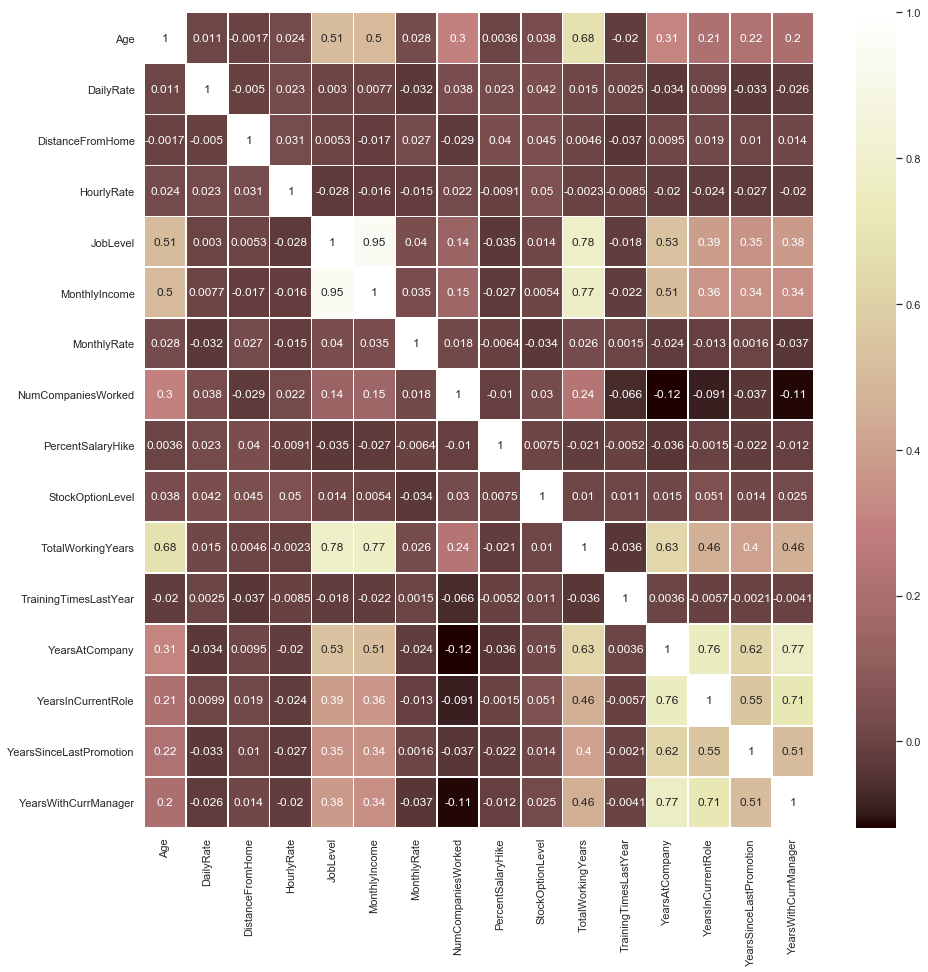

```python
f, ax = plt.subplots(figsize=(15, 15))
num_data_correlation_map = sns.heatmap(num_data_correlation, annot=True, linewidths=.5, ax=ax, cmap="pink")
num_data_correlation_map     # Should I include 'StandardHours'???
```

The results:  
The following is the list of some of the clumns in the order of highest correlations:  
(1) JobLevel and MonthlyIncome (0.95)  
(2) JobLevel and TotalWorkingYears (0.78)  
(3) MonthlyIncome and TotalWorkingYears (0.77)  
(4) YearsAtCompany and YearsWithCurrManager (0.77)  
(5) YearsAtCompany and YearsInCurrentRole (0.76)  
(6) YearsWithCurrManager and YearsInCurrentRole (0.71)

Analysis and interpretations:

- JobLevel is highly correlated to MonthlyIncome and TotalWorkingYears: This result is likely because that the longer you serve, the higher you are likely to be promoted. And higher your positon is, the more you are likely to earn as well. This intuitive result also explains the high correlation in (3) MonthlyIncome and TotalWorkingYears (0.77).
- Some of the "Years" columns are highly correlated with each other. For example, YearsAtCompany are highly correlated to YearsWithCurrentManager and YearsInCurrentRole. These correlations are interesting in that YearsAtCompany can be affected either positively and negatively. For example, if YearsAtCompany is long, it may also be the case that YearsWithCurrManager if you like working for your manager.  
  But the opposite can be true and both YearsAtCompany and YearsWithCurrManager may be short if you do not like working for your manager. A similar case can be made the relationshp between YearsWithCurrManager and YearsInCurrentRole.

The important thing to note as result of this correlationmap is that there appears to be many interrelationships at work, which makes the analysis challenging.

### Investigating Correlation for categorical data:

Several columns have categorical data as follows:  
Education: 1 'Below College' 2 'College' 3 'Bachelor' 4 'Master' 5 'Doctor'  
EnvironmentSatisfaction: 1 'Low' 2 'Medium' 3 'High' 4 'Very High'  
JobInvolvement: 1 'Low' 2 'Medium' 3 'High' 4 'Very High'  
JobSatisfaction: 1 'Low' 2 'Medium' 3 'High' 4 'Very High'  
PerformanceRating: 1 'Low' 2 'Good' 3 'Excellent' 4 'Outstanding'  
RelationshipSatisfaction: 1 'Low' 2 'Medium' 3 'High' 4 'Very High'  
WorkLifeBalance: 1 'Bad' 2 'Good' 3 'Better' 4 'Best'

```python
categorical_data_correlation = categorical_data.corr()
```

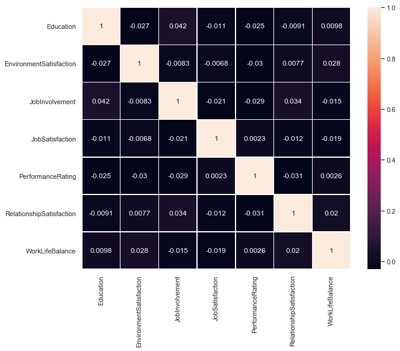

```python
f, ax = plt.subplots(figsize=(10, 8))
sns.heatmap(categorical_data_correlation, annot=True, linewidths=.5, ax=ax)
```

Result: The above map did not show anything interesting in temrs of correlations. This is because that the columns are categorical. The correlation mapping is not suiitable for the categorical data. As an experiment, the following K-Means Clustering is performed to see if it shows some interesting and visible clusters.

## K-Means (Clustering)

This section experimental to see if a quick K-Means Clustering would yield any interesting clusters.

Process:  
(1) Use the rule of the thumb to calculate the number of potential clusters.  
(2) The elbow plot will be drawn.  
(3) To analyze categorical data for K-Means Clustering, the column, 'Gender' Female/Male needs to be convered in 0 and 1 while Attrition column needs to be dropped for elbow plot.  
The attrition column, 'Attrtion' column will be later convered to Yes:1 and No:0 and used

```python
ruleofthumb = np.sqrt(1470)
ruleofthumb
```

```
38.34057902536163
```

The rule of thum suggests that the number of cluster is 38.

```python
categorical_data.loc[:, 'Gender'] = categorical_data.replace({'Male': 1, 'Female': 0})
dropped_attrition = categorical_data.drop('Attrition', axis=1)
dropped_attrition.head()
```

| EmployeeNumber | Gender | Education | EnvironmentSatisfaction | JobInvolvement | JobSatisfaction | PerformanceRating | RelationshipSatisfaction | WorkLifeBalance |
| --- | --- | --- | --- | --- | --- | --- | --- | --- |
| 1 | 0 | 2 | 2 | 3 | 4 | 3 | 1 | 1 |
| 2 | 1 | 1 | 3 | 2 | 2 | 4 | 4 | 3 |
| 4 | 1 | 2 | 4 | 2 | 3 | 3 | 2 | 3 |
| 5 | 0 | 4 | 4 | 3 | 3 | 3 | 3 | 3 |
| 7 | 1 | 1 | 1 | 3 | 2 | 3 | 4 | 3 |

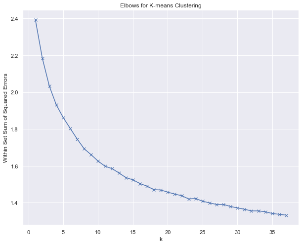

```python
### K-means may be sufficient.
import sklearn as sk
from sklearn import metrics

# Insert your code here
#sklearn.metrics.silhouette_score(X, labels, metric=’euclidean’
#, sample_size=None, random_state=None, **kwds)


from sklearn.cluster import KMeans
from sklearn import metrics
from scipy.spatial.distance import cdist
import numpy as np
import matplotlib.pyplot as plt


#K-means: Derermine K:
distortions = []
K = range(1,38)
for k in K:
    kmeanModel = KMeans(n_clusters=k)
    kmeanModel.fit(dropped_attrition)
    distortions.append(sum(np.min(cdist(dropped_attrition, kmeanModel.cluster_centers_, 'euclidean'), axis=1)) / dropped_attrition.shape[0])

# Elbow:
fig, axix = plt.subplots(figsize=(10, 8))
plt.plot(K, distortions, 'bx-')
plt.xlabel('k')
plt.ylabel('Within Set Sum of Squared Errors')
plt.title('Elbows for K-means Clustering')
plt.show()
```

The above elbow plot suggests the 5 cluster, which will be used below. The resulting clusters with respective assigned cluster numbers are added in kmeans_2 column below.

```python
dropped_attrition = categorical_data.drop('Attrition', axis=1)
dropped_attrition.head()
```

| EmployeeNumber | Gender | Education | EnvironmentSatisfaction | JobInvolvement | JobSatisfaction | PerformanceRating | RelationshipSatisfaction | WorkLifeBalance |
| --- | --- | --- | --- | --- | --- | --- | --- | --- |
| 1 | 0 | 2 | 2 | 3 | 4 | 3 | 1 | 1 |
| 2 | 1 | 1 | 3 | 2 | 2 | 4 | 4 | 3 |
| 4 | 1 | 2 | 4 | 2 | 3 | 3 | 2 | 3 |
| 5 | 0 | 4 | 4 | 3 | 3 | 3 | 3 | 3 |
| 7 | 1 | 1 | 1 | 3 | 2 | 3 | 4 | 3 |

```python
categorical_data.loc[:, 'Attrition'] = categorical_data.replace({'Yes': 1, 'No': 0})
```

```python
#K-means: Derermine K:
kmeanModel = KMeans(n_clusters=5)
kmeanModel.fit(categorical_data)
categorical_data.loc[:, 'kmeans_2'] = kmeanModel.predict(categorical_data)
categorical_data.loc[:, 'Attrition'] = categorical_data['Attrition']
categorical_data.head(20)
```

| EmployeeNumber | Attrition | Gender | Education | EnvironmentSatisfaction | JobInvolvement | JobSatisfaction | PerformanceRating | RelationshipSatisfaction | WorkLifeBalance | kmeans_2 |
| --- | --- | --- | --- | --- | --- | --- | --- | --- | --- | --- |
| 1 | 1 | 0 | 2 | 2 | 3 | 4 | 3 | 1 | 1 | 4 |
| 2 | 0 | 1 | 1 | 3 | 2 | 2 | 4 | 4 | 3 | 1 |
| 4 | 1 | 1 | 2 | 4 | 2 | 3 | 3 | 2 | 3 | 4 |
| 5 | 0 | 0 | 4 | 4 | 3 | 3 | 3 | 3 | 3 | 3 |
| 7 | 0 | 1 | 1 | 1 | 3 | 2 | 3 | 4 | 3 | 0 |
| 8 | 0 | 1 | 2 | 4 | 3 | 4 | 3 | 3 | 2 | 3 |
| 10 | 0 | 0 | 3 | 3 | 4 | 1 | 4 | 1 | 2 | 2 |
| 11 | 0 | 1 | 1 | 4 | 3 | 3 | 4 | 2 | 3 | 4 |
| 12 | 0 | 1 | 3 | 4 | 2 | 3 | 4 | 2 | 3 | 4 |
| 13 | 0 | 1 | 3 | 3 | 3 | 3 | 3 | 2 | 2 | 4 |
| 14 | 0 | 1 | 3 | 1 | 4 | 2 | 3 | 3 | 3 | 0 |
| 15 | 0 | 0 | 2 | 4 | 2 | 3 | 3 | 4 | 3 | 3 |
| 16 | 0 | 1 | 1 | 1 | 3 | 3 | 3 | 4 | 2 | 0 |
| 18 | 0 | 1 | 2 | 2 | 3 | 4 | 3 | 3 | 3 | 0 |
| 19 | 1 | 1 | 3 | 3 | 2 | 3 | 3 | 2 | 3 | 4 |
| 20 | 0 | 0 | 4 | 2 | 4 | 1 | 3 | 3 | 3 | 1 |
| 21 | 0 | 1 | 2 | 1 | 4 | 2 | 3 | 4 | 2 | 0 |
| 22 | 0 | 1 | 2 | 4 | 4 | 4 | 3 | 2 | 2 | 4 |
| 23 | 0 | 0 | 4 | 1 | 2 | 4 | 3 | 3 | 3 | 0 |
| 24 | 0 | 1 | 3 | 4 | 3 | 4 | 3 | 3 | 3 | 3 |

Together with K-clustering, the following PCA is performed with the 3D visualized result.

```python
pca_model = skd.PCA().fit(dropped_attrition)
pca_model.components_.shape
```

```
(8, 8)
```

```python
pca_model.explained_variance_
# the first four variances below are explaiend well by pca.
```

```
array([1.22597269, 1.20092464, 1.16465519, 1.04299838, 0.50954755,
       0.49158964, 0.23947231, 0.12964874])
```

As the above results from .explained_varience_shows, the four variances are qualified (the numbers above 1.0) and explained well by PCA: 1.22597269, 1.20092464, 1.16465519, 1.04299838

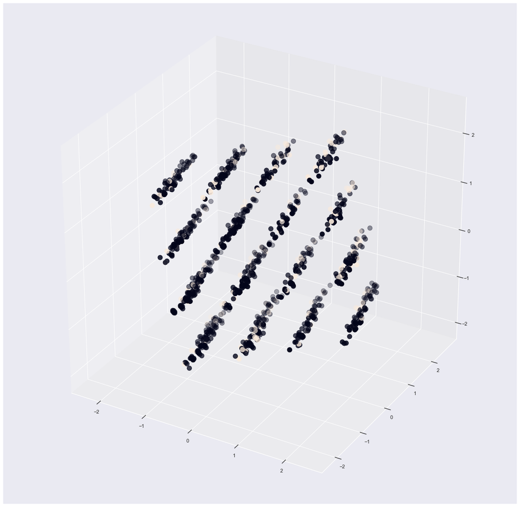

```python
X = pca_model.transform(dropped_attrition)

fig = plt.figure(figsize=(20, 20))
ax = fig.add_subplot(111, projection='3d')
ax.scatter(X[:,0], X[:,1], X[:,2], c=categorical_data['Attrition'].astype('category'), s=100)

for i, s in enumerate(categorical_data.index):
    x, y, _ = proj3d.proj_transform(X[i,0],X[i,1],X[i,2],
                                    ax.get_proj())
    #plt.annotate(s, xy=(x-0.005,y+0.002), fontsize=1)
```

Unfortunately, no apparent patterns were found, which may be due to the fact that the dataset has cerain complexies that could not have beene explained within the 3D space.

Next, as the final task, Random Forest Classification is performed to calculate the feature importance for Attrition.

## Classifications

### Random Forest to predict most important features 'Attrition':

```python
# First, perform random forest the way it is, and can perform with pd.get_dummies for (e.g.) JobLevel.
from sklearn.ensemble import RandomForestClassifier
```

```python
rf_data = pd.concat([number_data, categorical_data], axis=1)
rf_data.head()
```

| EmployeeNumber | Age | DailyRate | DistanceFromHome | HourlyRate | JobLevel | MonthlyIncome | MonthlyRate | NumCompaniesWorked | PercentSalaryHike | StockOptionLevel | ... | Attrition | Gender | Education | EnvironmentSatisfaction | JobInvolvement | JobSatisfaction | PerformanceRating | RelationshipSatisfaction | WorkLifeBalance | kmeans_2 |
| --- | --- | --- | --- | --- | --- | --- | --- | --- | --- | --- | --- | --- | --- | --- | --- | --- | --- | --- | --- | --- | --- |
| 1 | 41 | 1102 | 1 | 94 | 2 | 5993 | 19479 | 8 | 11 | 0 | ... | 1 | 0 | 2 | 2 | 3 | 4 | 3 | 1 | 1 | 4 |
| 2 | 49 | 279 | 8 | 61 | 2 | 5130 | 24907 | 1 | 23 | 1 | ... | 0 | 1 | 1 | 3 | 2 | 2 | 4 | 4 | 3 | 1 |
| 4 | 37 | 1373 | 2 | 92 | 1 | 2090 | 2396 | 6 | 15 | 0 | ... | 1 | 1 | 2 | 4 | 2 | 3 | 3 | 2 | 3 | 4 |
| 5 | 33 | 1392 | 3 | 56 | 1 | 2909 | 23159 | 1 | 11 | 0 | ... | 0 | 0 | 4 | 4 | 3 | 3 | 3 | 3 | 3 | 3 |
| 7 | 27 | 591 | 2 | 40 | 1 | 3468 | 16632 | 9 | 12 | 1 | ... | 0 | 1 | 1 | 1 | 3 | 2 | 3 | 4 | 3 | 0 |

5 rows × 26 columns

```python
X = rf_data.drop(['Attrition', 'kmeans_2'], axis=1)
y = rf_data['Attrition']
X_train, X_test, y_train, y_test = train_test_split(X, y, test_size=0.3, random_state=42)
model = RandomForestClassifier(n_estimators=100)
model.fit(X_train, y_train)
```

```
RandomForestClassifier(bootstrap=True, class_weight=None, criterion='gini',
            max_depth=None, max_features='auto', max_leaf_nodes=None,
            min_impurity_decrease=0.0, min_impurity_split=None,
            min_samples_leaf=1, min_samples_split=2,
            min_weight_fraction_leaf=0.0, n_estimators=100, n_jobs=None,
            oob_score=False, random_state=None, verbose=0,
            warm_start=False)
```

```python
feat_importance = sorted(list(zip(X_train.columns, model.feature_importances_)), key=lambda x: x[1], reverse=True)
feat_importance
```

```
[('MonthlyIncome', 0.09379283008900413),
 ('Age', 0.07683870994510993),
 ('MonthlyRate', 0.06662225205773609),
 ('DailyRate', 0.06650441578321957),
 ('HourlyRate', 0.06038339502709399),
 ('TotalWorkingYears', 0.058804030061166176),
 ('DistanceFromHome', 0.05694604928129479),
 ('StockOptionLevel', 0.04671605989505792),
 ('YearsAtCompany', 0.04550911339400427),
 ('PercentSalaryHike', 0.04478360732430316),
 ('NumCompaniesWorked', 0.043924822978152006),
 ('YearsInCurrentRole', 0.03772494749683493),
 ('YearsWithCurrManager', 0.03762775548739895),
 ('JobSatisfaction', 0.03250515707774317),
 ('TrainingTimesLastYear', 0.032204545361074324),
 ('EnvironmentSatisfaction', 0.03083096818778214),
 ('YearsSinceLastPromotion', 0.02912700440222398),
 ('JobInvolvement', 0.02834863436501242),
 ('RelationshipSatisfaction', 0.025315916283770886),
 ('WorkLifeBalance', 0.02462336240645489),
 ('JobLevel', 0.02176025573458919),
 ('Education', 0.020531780653247397),
 ('Gender', 0.01326538472757025),
 ('PerformanceRating', 0.0053090019801554636)]
```

Finally, the accuracy score is calculated to see if the results are reliable.

```python
model.score(X_train, y_train), model.score(X_test, y_test)
```

```
(1.0, 0.8594104308390023)
```

(End of Report)